# SQ 027

## Shared Qs (027)

#### Question

1. In Calculus, when [integrating](https://en.wikipedia.org/wiki/Integral) [rational expressions](https://en.wikipedia.org/wiki/Algebraic_fraction#Rational_fractions), it is often helpful to perform [partial-fraction decomposition](https://openstax.org/books/precalculus-2e/pages/9-4-partial-fractions). The simplest version of partial-fraction decomposition occurs when there are two distinct linear factors.

   The procedure can be exemplified by trying to determine constants $A$ and $B$ to satisfy the equation below **for all** values of $x$ (with restrictions $x\ne -7$ and $x\ne 2$).

   $$\frac{3x-33}{(x+7)(x-2)} = \frac{A}{x+7}+\frac{B}{x-2}$$
   - $A=$
   - $B=$

#### Solution

#### Question

2. In Calculus, when [integrating](https://en.wikipedia.org/wiki/Integral) [rational expressions](https://en.wikipedia.org/wiki/Algebraic_fraction#Rational_fractions), it is often helpful to perform [partial-fraction decomposition](https://openstax.org/books/precalculus-2e/pages/9-4-partial-fractions). The simplest version of partial-fraction decomposition occurs when there are two distinct linear factors.

   The procedure can be exemplified by trying to determine constants $A$ and $B$ to satisfy the equation below **for all** values of $x$ (with restrictions $x\ne -5$ and $x\ne -8$).

   $$\frac{5x+46}{(x+5)(x+8)} = \frac{A}{x+5}+\frac{B}{x+8}$$
   - $A=$
   - $B=$

#### Solution

#### Question

3. In Calculus, when [integrating](https://en.wikipedia.org/wiki/Integral) [rational expressions](https://en.wikipedia.org/wiki/Algebraic_fraction#Rational_fractions), it is often helpful to perform [partial-fraction decomposition](https://openstax.org/books/precalculus-2e/pages/9-4-partial-fractions). The simplest version of partial-fraction decomposition occurs when there are two distinct linear factors.

   The procedure can be exemplified by trying to determine constants $A$ and $B$ to satisfy the equation below **for all** values of $x$ (with restrictions $x\ne 2$ and $x\ne -9$).

   $$\frac{-12x-64}{(x-2)(x+9)} = \frac{A}{x-2}+\frac{B}{x+9}$$
   - $A=$
   - $B=$

#### Solution

#### Question

4. In Calculus, when [integrating](https://en.wikipedia.org/wiki/Integral) [rational expressions](https://en.wikipedia.org/wiki/Algebraic_fraction#Rational_fractions), it is often helpful to perform [partial-fraction decomposition](https://openstax.org/books/precalculus-2e/pages/9-4-partial-fractions). The simplest version of partial-fraction decomposition occurs when there are two distinct linear factors.

   The procedure can be exemplified by trying to determine constants $A$ and $B$ to satisfy the equation below **for all** values of $x$ (with restrictions $x\ne 6$ and $x\ne -2$).

   $$\frac{13x-38}{(x-6)(x+2)} = \frac{A}{x-6}+\frac{B}{x+2}$$
   - $A=$
   - $B=$

#### Solution

#### Question

5. In Calculus, when [integrating](https://en.wikipedia.org/wiki/Integral) [rational expressions](https://en.wikipedia.org/wiki/Algebraic_fraction#Rational_fractions), it is often helpful to perform [partial-fraction decomposition](https://openstax.org/books/precalculus-2e/pages/9-4-partial-fractions). The simplest version of partial-fraction decomposition occurs when there are two distinct linear factors.

   The procedure can be exemplified by trying to determine constants $A$ and $B$ to satisfy the equation below **for all** values of $x$ (with restrictions $x\ne 3$ and $x\ne -7$).

   $$\frac{-7x-29}{(x-3)(x+7)} = \frac{A}{x-3}+\frac{B}{x+7}$$
   - $A=$
   - $B=$

#### Solution

#### Question

6. In Calculus, when [integrating](https://en.wikipedia.org/wiki/Integral) [rational expressions](https://en.wikipedia.org/wiki/Algebraic_fraction#Rational_fractions), it is often helpful to perform [partial-fraction decomposition](https://openstax.org/books/precalculus-2e/pages/9-4-partial-fractions). The simplest version of partial-fraction decomposition occurs when there are two distinct linear factors.

   The procedure can be exemplified by trying to determine constants $A$ and $B$ to satisfy the equation below **for all** values of $x$ (with restrictions $x\ne -6$ and $x\ne -9$).

   $$\frac{9x+60}{(x+6)(x+9)} = \frac{A}{x+6}+\frac{B}{x+9}$$
   - $A=$
   - $B=$

#### Solution

#### Question

7. In Calculus, when [integrating](https://en.wikipedia.org/wiki/Integral) [rational expressions](https://en.wikipedia.org/wiki/Algebraic_fraction#Rational_fractions), it is often helpful to perform [partial-fraction decomposition](https://openstax.org/books/precalculus-2e/pages/9-4-partial-fractions). The simplest version of partial-fraction decomposition occurs when there are two distinct linear factors.

   The procedure can be exemplified by trying to determine constants $A$ and $B$ to satisfy the equation below **for all** values of $x$ (with restrictions $x\ne 2$ and $x\ne 6$).

   $$\frac{13x-42}{(x-2)(x-6)} = \frac{A}{x-2}+\frac{B}{x-6}$$
   - $A=$
   - $B=$

#### Solution

#### Question

8. In Calculus, when [integrating](https://en.wikipedia.org/wiki/Integral) [rational expressions](https://en.wikipedia.org/wiki/Algebraic_fraction#Rational_fractions), it is often helpful to perform [partial-fraction decomposition](https://openstax.org/books/precalculus-2e/pages/9-4-partial-fractions). The simplest version of partial-fraction decomposition occurs when there are two distinct linear factors.

   The procedure can be exemplified by trying to determine constants $A$ and $B$ to satisfy the equation below **for all** values of $x$ (with restrictions $x\ne -8$ and $x\ne 3$).

   $$\frac{13x+60}{(x+8)(x-3)} = \frac{A}{x+8}+\frac{B}{x-3}$$
   - $A=$
   - $B=$

#### Solution

#### Question

9. In Calculus, when [integrating](https://en.wikipedia.org/wiki/Integral) [rational expressions](https://en.wikipedia.org/wiki/Algebraic_fraction#Rational_fractions), it is often helpful to perform [partial-fraction decomposition](https://openstax.org/books/precalculus-2e/pages/9-4-partial-fractions). The simplest version of partial-fraction decomposition occurs when there are two distinct linear factors.

   The procedure can be exemplified by trying to determine constants $A$ and $B$ to satisfy the equation below **for all** values of $x$ (with restrictions $x\ne 9$ and $x\ne 5$).

   $$\frac{-4x+52}{(x-9)(x-5)} = \frac{A}{x-9}+\frac{B}{x-5}$$
   - $A=$
   - $B=$

#### Solution

#### Question

10. In Calculus, when [integrating](https://en.wikipedia.org/wiki/Integral) [rational expressions](https://en.wikipedia.org/wiki/Algebraic_fraction#Rational_fractions), it is often helpful to perform [partial-fraction decomposition](https://openstax.org/books/precalculus-2e/pages/9-4-partial-fractions). The simplest version of partial-fraction decomposition occurs when there are two distinct linear factors.

    The procedure can be exemplified by trying to determine constants $A$ and $B$ to satisfy the equation below **for all** values of $x$ (with restrictions $x\ne -5$ and $x\ne -2$).

    $$\frac{-15x-51}{(x+5)(x+2)} = \frac{A}{x+5}+\frac{B}{x+2}$$
    - $A=$
    - $B=$

#### Solution

#### Question

11. In Calculus, when [integrating](https://en.wikipedia.org/wiki/Integral) [rational expressions](https://en.wikipedia.org/wiki/Algebraic_fraction#Rational_fractions), it is often helpful to perform [partial-fraction decomposition](https://openstax.org/books/precalculus-2e/pages/9-4-partial-fractions). One version of partial-fraction decomposition occurs when there is a squared linear factor.

    The procedure can be exemplified by trying to determine constants $A$ and $B$ to satisfy the equation below **for all** values of $x$ (with restriction $x\ne 3$). It should be said that knowing/remembering how to set up the equation below is the hardest part of partial-fraction decomposition.

    $$\frac{-4x+18}{(x-3)^2} ~=~ \frac{A}{(x-3)}+\frac{B}{(x-3)^2}$$
    - $A=$
    - $B=$

#### Solution

#### Question

12. In Calculus, when [integrating](https://en.wikipedia.org/wiki/Integral) [rational expressions](https://en.wikipedia.org/wiki/Algebraic_fraction#Rational_fractions), it is often helpful to perform [partial-fraction decomposition](https://openstax.org/books/precalculus-2e/pages/9-4-partial-fractions). One version of partial-fraction decomposition occurs when there is a squared linear factor.

    The procedure can be exemplified by trying to determine constants $A$ and $B$ to satisfy the equation below **for all** values of $x$ (with restriction $x\ne 9$). It should be said that knowing/remembering how to set up the equation below is the hardest part of partial-fraction decomposition.

    $$\frac{3x-31}{(x-9)^2} ~=~ \frac{A}{(x-9)}+\frac{B}{(x-9)^2}$$
    - $A=$
    - $B=$

#### Solution

#### Question

13. In Calculus, when [integrating](https://en.wikipedia.org/wiki/Integral) [rational expressions](https://en.wikipedia.org/wiki/Algebraic_fraction#Rational_fractions), it is often helpful to perform [partial-fraction decomposition](https://openstax.org/books/precalculus-2e/pages/9-4-partial-fractions). One version of partial-fraction decomposition occurs when there is a squared linear factor.

    The procedure can be exemplified by trying to determine constants $A$ and $B$ to satisfy the equation below **for all** values of $x$ (with restriction $x\ne -7$). It should be said that knowing/remembering how to set up the equation below is the hardest part of partial-fraction decomposition.

    $$\frac{6x+33}{(x+7)^2} ~=~ \frac{A}{(x+7)}+\frac{B}{(x+7)^2}$$
    - $A=$
    - $B=$

#### Solution

#### Question

14. In Calculus, when [integrating](https://en.wikipedia.org/wiki/Integral) [rational expressions](https://en.wikipedia.org/wiki/Algebraic_fraction#Rational_fractions), it is often helpful to perform [partial-fraction decomposition](https://openstax.org/books/precalculus-2e/pages/9-4-partial-fractions). One version of partial-fraction decomposition occurs when there is a squared linear factor.

    The procedure can be exemplified by trying to determine constants $A$ and $B$ to satisfy the equation below **for all** values of $x$ (with restriction $x\ne 2$). It should be said that knowing/remembering how to set up the equation below is the hardest part of partial-fraction decomposition.

    $$\frac{3x-2}{(x-2)^2} ~=~ \frac{A}{(x-2)}+\frac{B}{(x-2)^2}$$
    - $A=$
    - $B=$

#### Solution

#### Question

15. In Calculus, when [integrating](https://en.wikipedia.org/wiki/Integral) [rational expressions](https://en.wikipedia.org/wiki/Algebraic_fraction#Rational_fractions), it is often helpful to perform [partial-fraction decomposition](https://openstax.org/books/precalculus-2e/pages/9-4-partial-fractions). One version of partial-fraction decomposition occurs when there is a squared linear factor.

    The procedure can be exemplified by trying to determine constants $A$ and $B$ to satisfy the equation below **for all** values of $x$ (with restriction $x\ne 7$). It should be said that knowing/remembering how to set up the equation below is the hardest part of partial-fraction decomposition.

    $$\frac{-2x+10}{(x-7)^2} ~=~ \frac{A}{(x-7)}+\frac{B}{(x-7)^2}$$
    - $A=$
    - $B=$

#### Solution

#### Question

16. In Calculus, when [integrating](https://en.wikipedia.org/wiki/Integral) [rational expressions](https://en.wikipedia.org/wiki/Algebraic_fraction#Rational_fractions), it is often helpful to perform [partial-fraction decomposition](https://openstax.org/books/precalculus-2e/pages/9-4-partial-fractions). One version of partial-fraction decomposition occurs when there is a squared linear factor.

    The procedure can be exemplified by trying to determine constants $A$ and $B$ to satisfy the equation below **for all** values of $x$ (with restriction $x\ne 4$). It should be said that knowing/remembering how to set up the equation below is the hardest part of partial-fraction decomposition.

    $$\frac{-2x+16}{(x-4)^2} ~=~ \frac{A}{(x-4)}+\frac{B}{(x-4)^2}$$
    - $A=$
    - $B=$

#### Solution

#### Question

17. In Calculus, when [integrating](https://en.wikipedia.org/wiki/Integral) [rational expressions](https://en.wikipedia.org/wiki/Algebraic_fraction#Rational_fractions), it is often helpful to perform [partial-fraction decomposition](https://openstax.org/books/precalculus-2e/pages/9-4-partial-fractions). One version of partial-fraction decomposition occurs when there is a squared linear factor.

    The procedure can be exemplified by trying to determine constants $A$ and $B$ to satisfy the equation below **for all** values of $x$ (with restriction $x\ne -2$). It should be said that knowing/remembering how to set up the equation below is the hardest part of partial-fraction decomposition.

    $$\frac{-4x-3}{(x+2)^2} ~=~ \frac{A}{(x+2)}+\frac{B}{(x+2)^2}$$
    - $A=$
    - $B=$

#### Solution

#### Question

18. In Calculus, when [integrating](https://en.wikipedia.org/wiki/Integral) [rational expressions](https://en.wikipedia.org/wiki/Algebraic_fraction#Rational_fractions), it is often helpful to perform [partial-fraction decomposition](https://openstax.org/books/precalculus-2e/pages/9-4-partial-fractions). One version of partial-fraction decomposition occurs when there is a squared linear factor.

    The procedure can be exemplified by trying to determine constants $A$ and $B$ to satisfy the equation below **for all** values of $x$ (with restriction $x\ne 4$). It should be said that knowing/remembering how to set up the equation below is the hardest part of partial-fraction decomposition.

    $$\frac{8x-34}{(x-4)^2} ~=~ \frac{A}{(x-4)}+\frac{B}{(x-4)^2}$$
    - $A=$
    - $B=$

#### Solution

#### Question

19. In Calculus, when [integrating](https://en.wikipedia.org/wiki/Integral) [rational expressions](https://en.wikipedia.org/wiki/Algebraic_fraction#Rational_fractions), it is often helpful to perform [partial-fraction decomposition](https://openstax.org/books/precalculus-2e/pages/9-4-partial-fractions). One version of partial-fraction decomposition occurs when there is a squared linear factor.

    The procedure can be exemplified by trying to determine constants $A$ and $B$ to satisfy the equation below **for all** values of $x$ (with restriction $x\ne -6$). It should be said that knowing/remembering how to set up the equation below is the hardest part of partial-fraction decomposition.

    $$\frac{-9x-50}{(x+6)^2} ~=~ \frac{A}{(x+6)}+\frac{B}{(x+6)^2}$$
    - $A=$
    - $B=$

#### Solution

#### Question

20. In Calculus, when [integrating](https://en.wikipedia.org/wiki/Integral) [rational expressions](https://en.wikipedia.org/wiki/Algebraic_fraction#Rational_fractions), it is often helpful to perform [partial-fraction decomposition](https://openstax.org/books/precalculus-2e/pages/9-4-partial-fractions). One version of partial-fraction decomposition occurs when there is a squared linear factor.

    The procedure can be exemplified by trying to determine constants $A$ and $B$ to satisfy the equation below **for all** values of $x$ (with restriction $x\ne 3$). It should be said that knowing/remembering how to set up the equation below is the hardest part of partial-fraction decomposition.

    $$\frac{9x-31}{(x-3)^2} ~=~ \frac{A}{(x-3)}+\frac{B}{(x-3)^2}$$
    - $A=$
    - $B=$

#### Solution

#### Question

21. Solve the system of linear equations.

    $$\begin{align}
    -5x-5y-5z&=-15 \\
    -6x-4y-6z&=-4 \\
    -x-2y+4z&=-10
    \end{align}$$
    - $x=$
    - $y=$
    - $z=$

#### Solution

#### Question

22. Solve the system of linear equations.

    $$\begin{align}
    3x+3y+4z&=-6 \\
    4x+4y+3z&=-1 \\
    5x+6y-z&=16
    \end{align}$$
    - $x=$
    - $y=$
    - $z=$

#### Solution

#### Question

23. Solve the system of linear equations.

    $$\begin{align}
    6x-2y+6z&=-12 \\
    x-2y+2z&=1 \\
    -4x-y+6z&=-5
    \end{align}$$
    - $x=$
    - $y=$
    - $z=$

#### Solution

#### Question

24. Solve the system of linear equations.

    $$\begin{align}
    x+2y+5z&=-14 \\
    -3x+y-2z&=-9 \\
    5x-2y+3z&=16
    \end{align}$$
    - $x=$
    - $y=$
    - $z=$

#### Solution

#### Question

25. Solve the system of linear equations.

    $$\begin{align}
    -3x+5y-5z&=19 \\
    -4x-y-z&=17 \\
    -2x+6y-5z&=18
    \end{align}$$
    - $x=$
    - $y=$
    - $z=$

#### Solution

#### Question

26. Solve the system of linear equations.

    $$\begin{align}
    -2x+2y+z&=-4 \\
    -6x-3y-6z&=-3 \\
    2x-y+2z&=3
    \end{align}$$
    - $x=$
    - $y=$
    - $z=$

#### Solution

#### Question

27. Solve the system of linear equations.

    $$\begin{align}
    4x-2y-3z&=-16 \\
    -6x+2y+z&=10 \\
    -6x-2y-5z&=-14
    \end{align}$$
    - $x=$
    - $y=$
    - $z=$

#### Solution

#### Question

28. Solve the system of linear equations.

    $$\begin{align}
    2x+2y-6z&=14 \\
    -2x+4y-3z&=-2 \\
    6x+6y+4z&=-2
    \end{align}$$
    - $x=$
    - $y=$
    - $z=$

#### Solution

#### Question

29. Solve the system of linear equations.

    $$\begin{align}
    -2x-y+3z&=-16 \\
    2x-2y+2z&=6 \\
    5x-2y+4z&=17
    \end{align}$$
    - $x=$
    - $y=$
    - $z=$

#### Solution

#### Question

30. Solve the system of linear equations.

    $$\begin{align}
    -4x+3y-4z&=-4 \\
    -6x-5y-3z&=9 \\
    6x-3y+4z&=-4
    \end{align}$$
    - $x=$
    - $y=$
    - $z=$

#### Solution

#### Question

31. Solve the system of linear equations.

    $$\begin{align}
    -w-3x-6y-2z&=25 \\
    -3w+5x-y-5z&=1 \\
    -3w-3x+4y-3z&=-59 \\
    4w-2x-y-2z&=-16
    \end{align}$$
    - $w=$
    - $x=$
    - $y=$
    - $z=$

#### Solution

#### Question

32. Solve the system of linear equations.

    $$\begin{align}
    4w+3x+y-5z&=22 \\
    w+x+y-z&=12 \\
    -2w-2x-5y-z&=-51 \\
    -4w+x-y-z&=-26
    \end{align}$$
    - $w=$
    - $x=$
    - $y=$
    - $z=$

#### Solution

#### Question

33. Solve the system of linear equations.

    $$\begin{align}
    w+3x-4y+3z&=83 \\
    -3w-4x-2y-3z&=-41 \\
    6w+x+6y-6z&=-76 \\
    -6w-2x-2y+z&=-3
    \end{align}$$
    - $w=$
    - $x=$
    - $y=$
    - $z=$

#### Solution

#### Question

34. Solve the system of linear equations.

    $$\begin{align}
    2w-4x+y+2z&=-3 \\
    2w-5x+4y+5z&=28 \\
    -5w+x-6y+z&=-51 \\
    -3w+x-6y-6z&=-70
    \end{align}$$
    - $w=$
    - $x=$
    - $y=$
    - $z=$

#### Solution

#### Question

35. Solve the system of linear equations.

    $$\begin{align}
    4w+3x+6y-6z&=77 \\
    -w-x-2y+5z&=-41 \\
    4w-6x+4y-4z&=38 \\
    2w-2x+2y+3z&=-8
    \end{align}$$
    - $w=$
    - $x=$
    - $y=$
    - $z=$

#### Solution

#### Question

36. Solve the system of linear equations.

    $$\begin{align}
    6w+6x-2y-6z&=-28 \\
    3w-3x+3y-4z&=64 \\
    -5w+4x+5y-4z&=23 \\
    w+x-y+3z&=-26
    \end{align}$$
    - $w=$
    - $x=$
    - $y=$
    - $z=$

#### Solution

#### Question

37. Solve the system of linear equations.

    $$\begin{align}
    6w+3x+2y+z&=4 \\
    w+6x-4y-6z&=-10 \\
    -2w-x-y+4z&=-3 \\
    -6w-x+4y+6z&=30
    \end{align}$$
    - $w=$
    - $x=$
    - $y=$
    - $z=$

#### Solution

#### Question

38. Solve the system of linear equations.

    $$\begin{align}
    -w+4x+6y-2z&=-67 \\
    3w+2x+2y+3z&=-49 \\
    3w-4x-4y+4z&=37 \\
    -6w+5x+2y+4z&=16
    \end{align}$$
    - $w=$
    - $x=$
    - $y=$
    - $z=$

#### Solution

#### Question

39. Solve the system of linear equations.

    $$\begin{align}
    w-5x-3y+3z&=-7 \\
    4w-4x-y+z&=-41 \\
    4w-3x-2y-5z&=-30 \\
    -4w+x-3y-z&=57
    \end{align}$$
    - $w=$
    - $x=$
    - $y=$
    - $z=$

#### Solution

#### Question

40. Solve the system of linear equations.

    $$\begin{align}
    -4w+x+2y+4z&=-16 \\
    -4w-4x-3y+3z&=5 \\
    -4w+5x+6y+4z&=-32 \\
    -2w+6x-2y+z&=-63
    \end{align}$$
    - $w=$
    - $x=$
    - $y=$
    - $z=$

#### Solution

#### Question

41. In Calculus, when [integrating](https://en.wikipedia.org/wiki/Integral) [rational expressions](https://en.wikipedia.org/wiki/Algebraic_fraction#Rational_fractions), it is often helpful to perform [partial-fraction decomposition](https://openstax.org/books/precalculus-2e/pages/9-4-partial-fractions).

    The procedure can be exemplified by trying to determine constants $A$, $B$, and $C$ to satisfy the equation below **for all** values of $x$.

    $$\frac{-13x^2-14x+3}{(x+3)(x-5)(x+2)} = \frac{A}{x+3}+\frac{B}{x-5}+\frac{C}{x+2}$$
    - $A=$
    - $B=$
    - $C=$

#### Solution

#### Question

42. In Calculus, when [integrating](https://en.wikipedia.org/wiki/Integral) [rational expressions](https://en.wikipedia.org/wiki/Algebraic_fraction#Rational_fractions), it is often helpful to perform [partial-fraction decomposition](https://openstax.org/books/precalculus-2e/pages/9-4-partial-fractions).

    The procedure can be exemplified by trying to determine constants $A$, $B$, and $C$ to satisfy the equation below **for all** values of $x$.

    $$\frac{-4x^2-9x+13}{(x+2)(x+5)(x+3)} = \frac{A}{x+2}+\frac{B}{x+5}+\frac{C}{x+3}$$
    - $A=$
    - $B=$
    - $C=$

#### Solution

#### Question

43. In Calculus, when [integrating](https://en.wikipedia.org/wiki/Integral) [rational expressions](https://en.wikipedia.org/wiki/Algebraic_fraction#Rational_fractions), it is often helpful to perform [partial-fraction decomposition](https://openstax.org/books/precalculus-2e/pages/9-4-partial-fractions).

    The procedure can be exemplified by trying to determine constants $A$, $B$, and $C$ to satisfy the equation below **for all** values of $x$.

    $$\frac{-5x^2-14x+12}{(x+6)(x+3)(x+2)} = \frac{A}{x+6}+\frac{B}{x+3}+\frac{C}{x+2}$$
    - $A=$
    - $B=$
    - $C=$

#### Solution

#### Question

44. In Calculus, when [integrating](https://en.wikipedia.org/wiki/Integral) [rational expressions](https://en.wikipedia.org/wiki/Algebraic_fraction#Rational_fractions), it is often helpful to perform [partial-fraction decomposition](https://openstax.org/books/precalculus-2e/pages/9-4-partial-fractions).

    The procedure can be exemplified by trying to determine constants $A$, $B$, and $C$ to satisfy the equation below **for all** values of $x$.

    $$\frac{-7x^2-9x+18}{(x-2)(x-3)(x+5)} = \frac{A}{x-2}+\frac{B}{x-3}+\frac{C}{x+5}$$
    - $A=$
    - $B=$
    - $C=$

#### Solution

#### Question

45. In Calculus, when [integrating](https://en.wikipedia.org/wiki/Integral) [rational expressions](https://en.wikipedia.org/wiki/Algebraic_fraction#Rational_fractions), it is often helpful to perform [partial-fraction decomposition](https://openstax.org/books/precalculus-2e/pages/9-4-partial-fractions).

    The procedure can be exemplified by trying to determine constants $A$, $B$, and $C$ to satisfy the equation below **for all** values of $x$.

    $$\frac{-4x^2+9x+19}{(x-2)(x-5)(x-3)} = \frac{A}{x-2}+\frac{B}{x-5}+\frac{C}{x-3}$$
    - $A=$
    - $B=$
    - $C=$

#### Solution

#### Question

46. In Calculus, when [integrating](https://en.wikipedia.org/wiki/Integral) [rational expressions](https://en.wikipedia.org/wiki/Algebraic_fraction#Rational_fractions), it is often helpful to perform [partial-fraction decomposition](https://openstax.org/books/precalculus-2e/pages/9-4-partial-fractions).

    The procedure can be exemplified by trying to determine constants $A$, $B$, and $C$ to satisfy the equation below **for all** values of $x$.

    $$\frac{-11x^2+8x+12}{(x+6)(x-2)(x-3)} = \frac{A}{x+6}+\frac{B}{x-2}+\frac{C}{x-3}$$
    - $A=$
    - $B=$
    - $C=$

#### Solution

#### Question

47. In Calculus, when [integrating](https://en.wikipedia.org/wiki/Integral) [rational expressions](https://en.wikipedia.org/wiki/Algebraic_fraction#Rational_fractions), it is often helpful to perform [partial-fraction decomposition](https://openstax.org/books/precalculus-2e/pages/9-4-partial-fractions).

    The procedure can be exemplified by trying to determine constants $A$, $B$, and $C$ to satisfy the equation below **for all** values of $x$.

    $$\frac{-10x^2-7x+5}{(x-5)(x+3)(x+2)} = \frac{A}{x-5}+\frac{B}{x+3}+\frac{C}{x+2}$$
    - $A=$
    - $B=$
    - $C=$

#### Solution

#### Question

48. In Calculus, when [integrating](https://en.wikipedia.org/wiki/Integral) [rational expressions](https://en.wikipedia.org/wiki/Algebraic_fraction#Rational_fractions), it is often helpful to perform [partial-fraction decomposition](https://openstax.org/books/precalculus-2e/pages/9-4-partial-fractions).

    The procedure can be exemplified by trying to determine constants $A$, $B$, and $C$ to satisfy the equation below **for all** values of $x$.

    $$\frac{3x^2+11x+16}{(x+2)(x+5)(x+3)} = \frac{A}{x+2}+\frac{B}{x+5}+\frac{C}{x+3}$$
    - $A=$
    - $B=$
    - $C=$

#### Solution

#### Question

49. In Calculus, when [integrating](https://en.wikipedia.org/wiki/Integral) [rational expressions](https://en.wikipedia.org/wiki/Algebraic_fraction#Rational_fractions), it is often helpful to perform [partial-fraction decomposition](https://openstax.org/books/precalculus-2e/pages/9-4-partial-fractions).

    The procedure can be exemplified by trying to determine constants $A$, $B$, and $C$ to satisfy the equation below **for all** values of $x$.

    $$\frac{-11x^2-11x+10}{(x-4)(x+2)(x+3)} = \frac{A}{x-4}+\frac{B}{x+2}+\frac{C}{x+3}$$
    - $A=$
    - $B=$
    - $C=$

#### Solution

#### Question

50. In Calculus, when [integrating](https://en.wikipedia.org/wiki/Integral) [rational expressions](https://en.wikipedia.org/wiki/Algebraic_fraction#Rational_fractions), it is often helpful to perform [partial-fraction decomposition](https://openstax.org/books/precalculus-2e/pages/9-4-partial-fractions).

    The procedure can be exemplified by trying to determine constants $A$, $B$, and $C$ to satisfy the equation below **for all** values of $x$.

    $$\frac{2x^2-3x+18}{(x-6)(x-3)(x-2)} = \frac{A}{x-6}+\frac{B}{x-3}+\frac{C}{x-2}$$
    - $A=$
    - $B=$
    - $C=$

#### Solution

#### Question

51. A matrix is a rectangular array of numbers. The dimensions of a matrix represent the number of rows and the number of columns (in that order!). Find the dimensions of the matrix below.

    $$\begin{bmatrix}
    -7 & 2 & 2\\
    -8 & -8 & -2
    \end{bmatrix}$$

    Dimensions: $\times$

#### Solution

#### Question

52. A matrix is a rectangular array of numbers. The dimensions of a matrix represent the number of rows and the number of columns (in that order!). Find the dimensions of the matrix below.

    $$\begin{bmatrix}
    6 & -8 & 1\\
    -3 & 5 & 9\\
    -2 & 9 & 8\\
    1 & -5 & 3\\
    0 & -4 & 3\\
    -3 & -8 & -3\\
    -2 & 5 & 1
    \end{bmatrix}$$

    Dimensions: $\times$

#### Solution

#### Question

53. A matrix is a rectangular array of numbers. The dimensions of a matrix represent the number of rows and the number of columns (in that order!). Find the dimensions of the matrix below.

    $$\begin{bmatrix}
    4 & -7 & -7 & 0 & -7 & -2 & -7\\
    -4 & 1 & -6 & 5 & -2 & -9 & -9\\
    7 & -8 & 9 & 5 & 9 & -6 & -1\\
    -2 & 7 & 3 & 3 & 5 & -4 & 8
    \end{bmatrix}$$

    Dimensions: $\times$

#### Solution

#### Question

54. A matrix is a rectangular array of numbers. The dimensions of a matrix represent the number of rows and the number of columns (in that order!). Find the dimensions of the matrix below.

    $$\begin{bmatrix}
    2 & 8 & -4 & -1 & 8 & -8 & -2\\
    3 & 1 & 3 & 7 & -4 & -9 & 0
    \end{bmatrix}$$

    Dimensions: $\times$

#### Solution

#### Question

55. A matrix is a rectangular array of numbers. The dimensions of a matrix represent the number of rows and the number of columns (in that order!). Find the dimensions of the matrix below.

    $$\begin{bmatrix}
    6 & -5 & -3 & -1 & 0 & 6 & 9\\
    -5 & 3 & 2 & 1 & 1 & 2 & -5\\
    9 & -7 & 1 & 4 & -2 & 9 & 3\\
    -7 & 9 & 1 & -2 & 7 & 5 & -3
    \end{bmatrix}$$

    Dimensions: $\times$

#### Solution

#### Question

56. A matrix is a rectangular array of numbers. The dimensions of a matrix represent the number of rows and the number of columns (in that order!). Find the dimensions of the matrix below.

    $$\begin{bmatrix}
    7 & 4 & -8 & 0 & 8 & 9 & -6\\
    3 & -4 & 8 & 0 & 2 & -5 & -3\\
    -1 & -7 & 2 & 8 & -9 & 2 & 5\\
    -8 & 2 & -6 & -8 & -6 & 5 & 6
    \end{bmatrix}$$

    Dimensions: $\times$

#### Solution

#### Question

57. A matrix is a rectangular array of numbers. The dimensions of a matrix represent the number of rows and the number of columns (in that order!). Find the dimensions of the matrix below.

    $$\begin{bmatrix}
    -1 & -1 & -2\\
    4 & -3 & 9\\
    -3 & 8 & -5\\
    0 & -4 & -2
    \end{bmatrix}$$

    Dimensions: $\times$

#### Solution

#### Question

58. A matrix is a rectangular array of numbers. The dimensions of a matrix represent the number of rows and the number of columns (in that order!). Find the dimensions of the matrix below.

    $$\begin{bmatrix}
    3 & 2 & 2 & -5 & 7 & -3\\
    7 & -5 & -5 & 5 & 2 & 3\\
    -8 & 3 & 4 & -7 & -7 & 8
    \end{bmatrix}$$

    Dimensions: $\times$

#### Solution

#### Question

59. A matrix is a rectangular array of numbers. The dimensions of a matrix represent the number of rows and the number of columns (in that order!). Find the dimensions of the matrix below.

    $$\begin{bmatrix}
    9 & 3 & 8 & -1 & -6\\
    -9 & 2 & 5 & 4 & -4
    \end{bmatrix}$$

    Dimensions: $\times$

#### Solution

#### Question

60. A matrix is a rectangular array of numbers. The dimensions of a matrix represent the number of rows and the number of columns (in that order!). Find the dimensions of the matrix below.

    $$\begin{bmatrix}
    -8 & 4 & -9 & -5\\
    0 & 3 & 8 & 3\\
    -8 & 0 & -4 & 2
    \end{bmatrix}$$

    Dimensions: $\times$

#### Solution

#### Question

61. If the dimensions of matrix $A$ are $m\times n$ and the dimensions of matrix $B$ are $p\times q$, then the [matrix-multiplication](https://en.wikipedia.org/wiki/Matrix_multiplication) $AB$ is only possible if $n=p$.

    $$A=\begin{bmatrix}
    -8 & -2\\
    -2 & -2\\
    -6 & 2
    \end{bmatrix}$$
    $$B=\begin{bmatrix}
    2 & 3 & 5 & 3\\
    -6 & 7 & 4 & -3\\
    -8 & 3 & -7 & -6\\
    -9 & -5 & -1 & 0\\
    0 & -1 & 5 & 3\\
    5 & 7 & 2 & -6
    \end{bmatrix}$$
    - $\mathrm{dim}(A)=$ $\times$
    - $\mathrm{dim}(B)=$ $\times$
    - Is the product $AB$ defined?

#### Solution

#### Question

62. If the dimensions of matrix $A$ are $m\times n$ and the dimensions of matrix $B$ are $p\times q$, then the [matrix-multiplication](https://en.wikipedia.org/wiki/Matrix_multiplication) $AB$ is only possible if $n=p$.

    $$A=\begin{bmatrix}
    7 & 3 & -4 & -1 & 6 & 8\\
    6 & -4 & 4 & -2 & -1 & 6
    \end{bmatrix}$$
    $$B=\begin{bmatrix}
    -4 & 3 & -3 & 0\\
    -6 & 4 & 9 & 2\\
    -8 & -3 & 2 & -9
    \end{bmatrix}$$
    - $\mathrm{dim}(A)=$ $\times$
    - $\mathrm{dim}(B)=$ $\times$
    - Is the product $AB$ defined?

#### Solution

#### Question

63. If the dimensions of matrix $A$ are $m\times n$ and the dimensions of matrix $B$ are $p\times q$, then the [matrix-multiplication](https://en.wikipedia.org/wiki/Matrix_multiplication) $AB$ is only possible if $n=p$.

    $$A=\begin{bmatrix}
    7 & -5 & 6 & 2\\
    8 & 0 & 7 & 0
    \end{bmatrix}$$
    $$B=\begin{bmatrix}
    8 & 1 & 2\\
    9 & 7 & -6\\
    3 & 9 & 3\\
    -4 & 9 & 3
    \end{bmatrix}$$
    - $\mathrm{dim}(A)=$ $\times$
    - $\mathrm{dim}(B)=$ $\times$
    - Is the product $AB$ defined?

#### Solution

#### Question

64. If the dimensions of matrix $A$ are $m\times n$ and the dimensions of matrix $B$ are $p\times q$, then the [matrix-multiplication](https://en.wikipedia.org/wiki/Matrix_multiplication) $AB$ is only possible if $n=p$.

    $$A=\begin{bmatrix}
    -4 & -8\\
    2 & 5\\
    -7 & -6
    \end{bmatrix}$$
    $$B=\begin{bmatrix}
    0 & -8 & -3 & -1 & -2\\
    6 & 6 & 0 & -6 & -6
    \end{bmatrix}$$
    - $\mathrm{dim}(A)=$ $\times$
    - $\mathrm{dim}(B)=$ $\times$
    - Is the product $AB$ defined?

#### Solution

#### Question

65. If the dimensions of matrix $A$ are $m\times n$ and the dimensions of matrix $B$ are $p\times q$, then the [matrix-multiplication](https://en.wikipedia.org/wiki/Matrix_multiplication) $AB$ is only possible if $n=p$.

    $$A=\begin{bmatrix}
    -2 & 6 & -3 & -2 & -8 & 1\\
    0 & 4 & -3 & 2 & -1 & -2\\
    6 & -9 & 3 & 3 & 6 & -4\\
    -1 & 1 & 8 & -2 & -3 & -3\\
    4 & 4 & -4 & 5 & 5 & 0
    \end{bmatrix}$$
    $$B=\begin{bmatrix}
    0 & 1 & -5\\
    -9 & 6 & -9\\
    -4 & -3 & -6\\
    -7 & -3 & -7\\
    3 & -8 & 5\\
    5 & -6 & -6
    \end{bmatrix}$$
    - $\mathrm{dim}(A)=$ $\times$
    - $\mathrm{dim}(B)=$ $\times$
    - Is the product $AB$ defined?

#### Solution

#### Question

66. If the dimensions of matrix $A$ are $m\times n$ and the dimensions of matrix $B$ are $p\times q$, then the [matrix-multiplication](https://en.wikipedia.org/wiki/Matrix_multiplication) $AB$ is only possible if $n=p$.

    $$A=\begin{bmatrix}
    -9 & 3 & 8 & -3 & 9 & 0\\
    6 & 8 & -3 & -5 & 0 & 1\\
    -9 & 4 & -7 & -7 & 2 & -1
    \end{bmatrix}$$
    $$B=\begin{bmatrix}
    0 & 7 & -6 & 0 & 0\\
    -8 & 5 & 2 & -1 & -8\\
    5 & -3 & 7 & -1 & -2\\
    -4 & 5 & -7 & -9 & 1\\
    -8 & 6 & -3 & 9 & 7\\
    -1 & 8 & 7 & 8 & 7
    \end{bmatrix}$$
    - $\mathrm{dim}(A)=$ $\times$
    - $\mathrm{dim}(B)=$ $\times$
    - Is the product $AB$ defined?

#### Solution

#### Question

67. If the dimensions of matrix $A$ are $m\times n$ and the dimensions of matrix $B$ are $p\times q$, then the [matrix-multiplication](https://en.wikipedia.org/wiki/Matrix_multiplication) $AB$ is only possible if $n=p$.

    $$A=\begin{bmatrix}
    3 & 9 & 3 & -9 & 6\\
    3 & -5 & -7 & 9 & 8\\
    -8 & 6 & 0 & 4 & -7\\
    4 & -4 & -9 & -6 & -1
    \end{bmatrix}$$
    $$B=\begin{bmatrix}
    -8 & 0\\
    -1 & -1\\
    -1 & 8\\
    -8 & -1\\
    -9 & 5
    \end{bmatrix}$$
    - $\mathrm{dim}(A)=$ $\times$
    - $\mathrm{dim}(B)=$ $\times$
    - Is the product $AB$ defined?

#### Solution

#### Question

68. If the dimensions of matrix $A$ are $m\times n$ and the dimensions of matrix $B$ are $p\times q$, then the [matrix-multiplication](https://en.wikipedia.org/wiki/Matrix_multiplication) $AB$ is only possible if $n=p$.

    $$A=\begin{bmatrix}
    -6 & 7 & -1 & 7\\
    -7 & 7 & -5 & -7\\
    3 & 7 & 3 & -8\\
    8 & 7 & 4 & 5\\
    -8 & 3 & 4 & 7
    \end{bmatrix}$$
    $$B=\begin{bmatrix}
    -1 & -3 & -3\\
    -5 & -3 & 1\\
    -3 & 4 & 8\\
    3 & 3 & 7
    \end{bmatrix}$$
    - $\mathrm{dim}(A)=$ $\times$
    - $\mathrm{dim}(B)=$ $\times$
    - Is the product $AB$ defined?

#### Solution

#### Question

69. If the dimensions of matrix $A$ are $m\times n$ and the dimensions of matrix $B$ are $p\times q$, then the [matrix-multiplication](https://en.wikipedia.org/wiki/Matrix_multiplication) $AB$ is only possible if $n=p$.

    $$A=\begin{bmatrix}
    5 & 7 & 8 & 4 & 0 & 0\\
    6 & 6 & -8 & -9 & 5 & -4\\
    3 & 0 & 4 & 7 & -1 & -9
    \end{bmatrix}$$
    $$B=\begin{bmatrix}
    -2 & -4\\
    -5 & 7\\
    -8 & 6\\
    -7 & -9
    \end{bmatrix}$$
    - $\mathrm{dim}(A)=$ $\times$
    - $\mathrm{dim}(B)=$ $\times$
    - Is the product $AB$ defined?

#### Solution

#### Question

70. If the dimensions of matrix $A$ are $m\times n$ and the dimensions of matrix $B$ are $p\times q$, then the [matrix-multiplication](https://en.wikipedia.org/wiki/Matrix_multiplication) $AB$ is only possible if $n=p$.

    $$A=\begin{bmatrix}
    0 & 4 & -8 & -6 & -8\\
    -2 & 3 & -9 & 6 & -1\\
    1 & 1 & 2 & -9 & 1
    \end{bmatrix}$$
    $$B=\begin{bmatrix}
    9 & 0\\
    5 & -2\\
    -5 & 6\\
    -1 & 0\\
    -4 & -1\\
    4 & -3
    \end{bmatrix}$$
    - $\mathrm{dim}(A)=$ $\times$
    - $\mathrm{dim}(B)=$ $\times$
    - Is the product $AB$ defined?

#### Solution

#### Question

71. Matrices $A$ and $B$ are defined below.

    $$A = \begin{bmatrix}
    -1 & 0 & 1\\
    4 & 7 & 2
    \end{bmatrix}$$
    $$B = \begin{bmatrix}
    6 & -1 & 1 & 9\\
    6 & 3 & 7 & -4\\
    6 & -5 & -2 & 7
    \end{bmatrix}$$

    Find the [product](https://en.wikipedia.org/wiki/Matrix_multiplication) $C=AB$.

    $AB=$

#### Solution

#### Question

72. Matrices $A$ and $B$ are defined below.

    $$A = \begin{bmatrix}
    -2 & -2 & 7\\
    -3 & -7 & 4\\
    -2 & 6 & 5\\
    3 & -7 & 7
    \end{bmatrix}$$
    $$B = \begin{bmatrix}
    -9 & -4\\
    9 & 3\\
    0 & 8
    \end{bmatrix}$$

    Find the [product](https://en.wikipedia.org/wiki/Matrix_multiplication) $C=AB$.

    $AB=$

#### Solution

#### Question

73. Matrices $A$ and $B$ are defined below.

    $$A = \begin{bmatrix}
    0 & 4 & -1 & 3\\
    -6 & 8 & 0 & 7\\
    -8 & -8 & 2 & -2
    \end{bmatrix}$$
    $$B = \begin{bmatrix}
    -5 & -6\\
    -8 & -4\\
    0 & -3\\
    7 & 8
    \end{bmatrix}$$

    Find the [product](https://en.wikipedia.org/wiki/Matrix_multiplication) $C=AB$.

    $AB=$

#### Solution

#### Question

74. Matrices $A$ and $B$ are defined below.

    $$A = \begin{bmatrix}
    -6 & -4 & 0\\
    -3 & -6 & -3\\
    1 & 0 & -2\\
    7 & -4 & 0
    \end{bmatrix}$$
    $$B = \begin{bmatrix}
    -3 & -3\\
    -9 & 5\\
    1 & -1
    \end{bmatrix}$$

    Find the [product](https://en.wikipedia.org/wiki/Matrix_multiplication) $C=AB$.

    $AB=$

#### Solution

#### Question

75. Matrices $A$ and $B$ are defined below.

    $$A = \begin{bmatrix}
    -2 & 4 & 8 & -3\\
    -4 & -3 & 3 & 5\\
    7 & -1 & 1 & 9
    \end{bmatrix}$$
    $$B = \begin{bmatrix}
    -3 & -4\\
    5 & -8\\
    -7 & 1\\
    8 & -6
    \end{bmatrix}$$

    Find the [product](https://en.wikipedia.org/wiki/Matrix_multiplication) $C=AB$.

    $AB=$

#### Solution

#### Question

76. Matrices $A$ and $B$ are defined below.

    $$A = \begin{bmatrix}
    0 & 9 & 7\\
    2 & 8 & 9\\
    -1 & -4 & 9\\
    -3 & -9 & 8
    \end{bmatrix}$$
    $$B = \begin{bmatrix}
    -9 & 5\\
    7 & -3\\
    -1 & -7
    \end{bmatrix}$$

    Find the [product](https://en.wikipedia.org/wiki/Matrix_multiplication) $C=AB$.

    $AB=$

#### Solution

#### Question

77. Matrices $A$ and $B$ are defined below.

    $$A = \begin{bmatrix}
    5 & -3 & -2\\
    -3 & -9 & 7\\
    8 & 7 & -9\\
    7 & -8 & 2
    \end{bmatrix}$$
    $$B = \begin{bmatrix}
    -1 & 4\\
    -1 & 3\\
    1 & 8
    \end{bmatrix}$$

    Find the [product](https://en.wikipedia.org/wiki/Matrix_multiplication) $C=AB$.

    $AB=$

#### Solution

#### Question

78. Matrices $A$ and $B$ are defined below.

    $$A = \begin{bmatrix}
    -2 & 6\\
    5 & 0\\
    -1 & 1\\
    -1 & 3
    \end{bmatrix}$$
    $$B = \begin{bmatrix}
    0 & -5 & 9\\
    -1 & -7 & 6
    \end{bmatrix}$$

    Find the [product](https://en.wikipedia.org/wiki/Matrix_multiplication) $C=AB$.

    $AB=$

#### Solution

#### Question

79. Matrices $A$ and $B$ are defined below.

    $$A = \begin{bmatrix}
    -9 & 0\\
    0 & 2\\
    0 & -1
    \end{bmatrix}$$
    $$B = \begin{bmatrix}
    6 & -6 & 3 & 7\\
    -8 & -5 & 0 & 4
    \end{bmatrix}$$

    Find the [product](https://en.wikipedia.org/wiki/Matrix_multiplication) $C=AB$.

    $AB=$

#### Solution

#### Question

80. Matrices $A$ and $B$ are defined below.

    $$A = \begin{bmatrix}
    9 & -3 & 8\\
    -7 & 3 & -6\\
    4 & -3 & -5\\
    7 & 0 & -9
    \end{bmatrix}$$
    $$B = \begin{bmatrix}
    1 & -6\\
    6 & -7\\
    4 & -7
    \end{bmatrix}$$

    Find the [product](https://en.wikipedia.org/wiki/Matrix_multiplication) $C=AB$.

    $AB=$

#### Solution

#### Question

81. In a [15-minute city](https://en.wikipedia.org/wiki/15-minute_city), all the following grocery stores are within a quick walk, and their prices (in USD) for some foods are shown.

    |  | apple | banana | cherry | durian | eggplant | fig | grapefruit | honeydew |
    | --- | --- | --- | --- | --- | --- | --- | --- | --- |
    | Lovely Lunches | 1.19 | 0.84 | 6.24 | 9.22 | 4.01 | 3.70 | 2.28 | 4.79 |
    | More Munchies | 1.70 | 1.06 | 4.92 | 9.15 | 3.01 | 3.10 | 3.19 | 5.75 |
    | Nick’s Necessities | 1.52 | 0.81 | 5.12 | 7.53 | 3.13 | 4.95 | 2.33 | 6.97 |
    | Overpriced Options | 1.67 | 1.01 | 6.47 | 9.50 | 4.39 | 3.73 | 2.78 | 6.32 |
    | Price Pincher | 1.65 | 0.97 | 6.60 | 6.90 | 3.41 | 4.34 | 2.88 | 4.66 |

    Each of the people below plans to go shopping for those foods. Their grocery lists are shown.

    |  | Quintin | Rachel | Sebastian | Trevor | Ursula | Venus |
    | --- | --- | --- | --- | --- | --- | --- |
    | apple | 0 | 3 | 2 | 1 | 1 | 0 |
    | banana | 1 | 4 | 0 | 0 | 2 | 0 |
    | cherry | 0 | 1 | 4 | 0 | 2 | 1 |
    | durian | 1 | 2 | 0 | 4 | 0 | 4 |
    | eggplant | 0 | 0 | 2 | 2 | 4 | 2 |
    | fig | 3 | 1 | 0 | 3 | 0 | 0 |
    | grapefruit | 2 | 2 | 1 | 2 | 2 | 2 |
    | honeydew | 1 | 0 | 2 | 0 | 0 | 0 |

    We can create these matrices in [SageMath](https://chadworley.github.io/sage.html) using the following commands:

    ```
    P = matrix([[1.19,0.84,6.24,9.22,4.01,3.70,2.28,4.79],
                [1.70,1.06,4.92,9.15,3.01,3.10,3.19,5.75],
                [1.52,0.81,5.12,7.53,3.13,4.95,2.33,6.97],
                [1.67,1.01,6.47,9.50,4.39,3.73,2.78,6.32],
                [1.65,0.97,6.60,6.90,3.41,4.34,2.88,4.66]])

    Q = matrix([[0,3,2,1,1,0],
                [1,4,0,0,2,0],
                [0,1,4,0,2,1],
                [1,2,0,4,0,4],
                [0,0,2,2,4,2],
                [3,1,0,3,0,0],
                [2,2,1,2,2,2],
                [1,0,2,0,0,0]])
    ```

    We can find the product of these matrices.

    ```
    pretty_print(P*Q)
    ```

    What is the maximum possible cost of a grocery trip?

#### Solution

#### Question

82. In a [15-minute city](https://en.wikipedia.org/wiki/15-minute_city), all the following grocery stores are within a quick walk, and their prices (in USD) for some foods are shown.

    |  | apple | banana | cherry | durian | eggplant | fig | grapefruit | honeydew |
    | --- | --- | --- | --- | --- | --- | --- | --- | --- |
    | Lovely Lunches | 1.32 | 1.12 | 5.14 | 6.32 | 4.29 | 4.23 | 3.11 | 4.80 |
    | More Munchies | 1.42 | 0.91 | 7.23 | 8.07 | 3.74 | 4.63 | 2.52 | 4.50 |
    | Nick’s Necessities | 1.65 | 0.91 | 4.76 | 7.80 | 3.38 | 3.06 | 3.32 | 6.98 |
    | Overpriced Options | 1.78 | 1.01 | 6.84 | 6.16 | 4.97 | 4.06 | 2.83 | 6.52 |
    | Price Pincher | 1.61 | 0.70 | 6.17 | 8.39 | 4.46 | 4.29 | 3.04 | 5.96 |

    Each of the people below plans to go shopping for those foods. Their grocery lists are shown.

    |  | Quintin | Rachel | Sebastian | Trevor | Ursula | Venus |
    | --- | --- | --- | --- | --- | --- | --- |
    | apple | 1 | 1 | 0 | 1 | 1 | 4 |
    | banana | 0 | 1 | 2 | 0 | 4 | 0 |
    | cherry | 0 | 0 | 0 | 3 | 2 | 1 |
    | durian | 0 | 0 | 0 | 0 | 1 | 2 |
    | eggplant | 0 | 0 | 1 | 2 | 0 | 0 |
    | fig | 4 | 2 | 4 | 4 | 0 | 1 |
    | grapefruit | 3 | 1 | 2 | 2 | 2 | 0 |
    | honeydew | 1 | 4 | 0 | 2 | 0 | 1 |

    We can create these matrices in [SageMath](https://chadworley.github.io/sage.html) using the following commands:

    ```
    P = matrix([[1.32,1.12,5.14,6.32,4.29,4.23,3.11,4.80],
                [1.42,0.91,7.23,8.07,3.74,4.63,2.52,4.50],
                [1.65,0.91,4.76,7.80,3.38,3.06,3.32,6.98],
                [1.78,1.01,6.84,6.16,4.97,4.06,2.83,6.52],
                [1.61,0.70,6.17,8.39,4.46,4.29,3.04,5.96]])

    Q = matrix([[1,1,0,1,1,4],
                [0,1,2,0,4,0],
                [0,0,0,3,2,1],
                [0,0,0,0,1,2],
                [0,0,1,2,0,0],
                [4,2,4,4,0,1],
                [3,1,2,2,2,0],
                [1,4,0,2,0,1]])
    ```

    We can find the product of these matrices.

    ```
    pretty_print(P*Q)
    ```

    What is the maximum possible cost of a grocery trip?

#### Solution

#### Question

83. In a [15-minute city](https://en.wikipedia.org/wiki/15-minute_city), all the following grocery stores are within a quick walk, and their prices (in USD) for some foods are shown.

    |  | apple | banana | cherry | durian | eggplant | fig | grapefruit | honeydew |
    | --- | --- | --- | --- | --- | --- | --- | --- | --- |
    | Lovely Lunches | 1.79 | 0.85 | 7.24 | 9.56 | 4.73 | 4.92 | 2.96 | 4.88 |
    | More Munchies | 1.30 | 1.02 | 5.59 | 7.41 | 4.09 | 4.66 | 3.66 | 4.75 |
    | Nick’s Necessities | 1.23 | 0.77 | 7.04 | 9.19 | 3.63 | 4.30 | 2.27 | 5.79 |
    | Overpriced Options | 1.76 | 0.97 | 5.67 | 9.56 | 3.29 | 3.84 | 2.73 | 5.31 |
    | Price Pincher | 1.55 | 0.76 | 6.73 | 8.27 | 3.76 | 3.42 | 2.74 | 5.16 |

    Each of the people below plans to go shopping for those foods. Their grocery lists are shown.

    |  | Quintin | Rachel | Sebastian | Trevor | Ursula | Venus |
    | --- | --- | --- | --- | --- | --- | --- |
    | apple | 4 | 4 | 2 | 4 | 1 | 2 |
    | banana | 0 | 0 | 2 | 1 | 3 | 2 |
    | cherry | 0 | 0 | 1 | 0 | 0 | 1 |
    | durian | 2 | 2 | 0 | 0 | 2 | 0 |
    | eggplant | 2 | 2 | 2 | 0 | 0 | 4 |
    | fig | 3 | 3 | 1 | 2 | 1 | 1 |
    | grapefruit | 1 | 1 | 0 | 1 | 4 | 1 |
    | honeydew | 1 | 0 | 3 | 2 | 1 | 0 |

    We can create these matrices in [SageMath](https://chadworley.github.io/sage.html) using the following commands:

    ```
    P = matrix([[1.79,0.85,7.24,9.56,4.73,4.92,2.96,4.88],
                [1.30,1.02,5.59,7.41,4.09,4.66,3.66,4.75],
                [1.23,0.77,7.04,9.19,3.63,4.30,2.27,5.79],
                [1.76,0.97,5.67,9.56,3.29,3.84,2.73,5.31],
                [1.55,0.76,6.73,8.27,3.76,3.42,2.74,5.16]])

    Q = matrix([[4,4,2,4,1,2],
                [0,0,2,1,3,2],
                [0,0,1,0,0,1],
                [2,2,0,0,2,0],
                [2,2,2,0,0,4],
                [3,3,1,2,1,1],
                [1,1,0,1,4,1],
                [1,0,3,2,1,0]])
    ```

    We can find the product of these matrices.

    ```
    pretty_print(P*Q)
    ```

    What is the maximum possible cost of a grocery trip?

#### Solution

#### Question

84. In a [15-minute city](https://en.wikipedia.org/wiki/15-minute_city), all the following grocery stores are within a quick walk, and their prices (in USD) for some foods are shown.

    |  | apple | banana | cherry | durian | eggplant | fig | grapefruit | honeydew |
    | --- | --- | --- | --- | --- | --- | --- | --- | --- |
    | Lovely Lunches | 1.36 | 0.84 | 4.60 | 7.59 | 3.16 | 3.60 | 2.27 | 5.65 |
    | More Munchies | 1.38 | 0.99 | 4.86 | 8.83 | 4.54 | 4.50 | 2.54 | 6.01 |
    | Nick’s Necessities | 1.14 | 0.92 | 7.38 | 7.74 | 4.90 | 4.26 | 2.29 | 5.69 |
    | Overpriced Options | 1.22 | 0.85 | 6.79 | 7.52 | 3.17 | 3.24 | 2.49 | 5.76 |
    | Price Pincher | 1.85 | 0.70 | 4.55 | 9.10 | 4.35 | 3.79 | 2.39 | 4.64 |

    Each of the people below plans to go shopping for those foods. Their grocery lists are shown.

    |  | Quintin | Rachel | Sebastian | Trevor | Ursula | Venus |
    | --- | --- | --- | --- | --- | --- | --- |
    | apple | 0 | 2 | 2 | 1 | 4 | 0 |
    | banana | 4 | 0 | 2 | 4 | 1 | 1 |
    | cherry | 1 | 0 | 1 | 2 | 1 | 2 |
    | durian | 1 | 2 | 0 | 1 | 0 | 2 |
    | eggplant | 0 | 1 | 0 | 2 | 2 | 3 |
    | fig | 0 | 1 | 1 | 1 | 3 | 1 |
    | grapefruit | 0 | 0 | 4 | 0 | 0 | 1 |
    | honeydew | 2 | 1 | 1 | 2 | 1 | 4 |

    We can create these matrices in [SageMath](https://chadworley.github.io/sage.html) using the following commands:

    ```
    P = matrix([[1.36,0.84,4.60,7.59,3.16,3.60,2.27,5.65],
                [1.38,0.99,4.86,8.83,4.54,4.50,2.54,6.01],
                [1.14,0.92,7.38,7.74,4.90,4.26,2.29,5.69],
                [1.22,0.85,6.79,7.52,3.17,3.24,2.49,5.76],
                [1.85,0.70,4.55,9.10,4.35,3.79,2.39,4.64]])

    Q = matrix([[0,2,2,1,4,0],
                [4,0,2,4,1,1],
                [1,0,1,2,1,2],
                [1,2,0,1,0,2],
                [0,1,0,2,2,3],
                [0,1,1,1,3,1],
                [0,0,4,0,0,1],
                [2,1,1,2,1,4]])
    ```

    We can find the product of these matrices.

    ```
    pretty_print(P*Q)
    ```

    What is the maximum possible cost of a grocery trip?

#### Solution

#### Question

85. In a [15-minute city](https://en.wikipedia.org/wiki/15-minute_city), all the following grocery stores are within a quick walk, and their prices (in USD) for some foods are shown.

    |  | apple | banana | cherry | durian | eggplant | fig | grapefruit | honeydew |
    | --- | --- | --- | --- | --- | --- | --- | --- | --- |
    | Lovely Lunches | 1.83 | 0.91 | 6.73 | 7.81 | 4.23 | 4.77 | 3.21 | 5.05 |
    | More Munchies | 1.64 | 0.85 | 6.01 | 9.45 | 3.77 | 3.86 | 3.59 | 5.81 |
    | Nick’s Necessities | 1.73 | 1.09 | 5.98 | 8.48 | 3.62 | 3.39 | 3.34 | 5.19 |
    | Overpriced Options | 1.63 | 0.96 | 6.47 | 8.77 | 3.90 | 3.37 | 2.86 | 5.17 |
    | Price Pincher | 1.30 | 0.92 | 6.11 | 8.11 | 3.05 | 4.08 | 2.34 | 5.98 |

    Each of the people below plans to go shopping for those foods. Their grocery lists are shown.

    |  | Quintin | Rachel | Sebastian | Trevor | Ursula | Venus |
    | --- | --- | --- | --- | --- | --- | --- |
    | apple | 1 | 0 | 0 | 2 | 0 | 0 |
    | banana | 0 | 2 | 0 | 0 | 0 | 2 |
    | cherry | 4 | 4 | 1 | 0 | 1 | 1 |
    | durian | 1 | 1 | 0 | 1 | 2 | 0 |
    | eggplant | 0 | 0 | 4 | 1 | 2 | 4 |
    | fig | 3 | 0 | 2 | 0 | 2 | 1 |
    | grapefruit | 2 | 2 | 3 | 4 | 3 | 0 |
    | honeydew | 0 | 1 | 1 | 3 | 4 | 3 |

    We can create these matrices in [SageMath](https://chadworley.github.io/sage.html) using the following commands:

    ```
    P = matrix([[1.83,0.91,6.73,7.81,4.23,4.77,3.21,5.05],
                [1.64,0.85,6.01,9.45,3.77,3.86,3.59,5.81],
                [1.73,1.09,5.98,8.48,3.62,3.39,3.34,5.19],
                [1.63,0.96,6.47,8.77,3.90,3.37,2.86,5.17],
                [1.30,0.92,6.11,8.11,3.05,4.08,2.34,5.98]])

    Q = matrix([[1,0,0,2,0,0],
                [0,2,0,0,0,2],
                [4,4,1,0,1,1],
                [1,1,0,1,2,0],
                [0,0,4,1,2,4],
                [3,0,2,0,2,1],
                [2,2,3,4,3,0],
                [0,1,1,3,4,3]])
    ```

    We can find the product of these matrices.

    ```
    pretty_print(P*Q)
    ```

    What is the maximum possible cost of a grocery trip?

#### Solution

#### Question

86. In a [15-minute city](https://en.wikipedia.org/wiki/15-minute_city), all the following grocery stores are within a quick walk, and their prices (in USD) for some foods are shown.

    |  | apple | banana | cherry | durian | eggplant | fig | grapefruit | honeydew |
    | --- | --- | --- | --- | --- | --- | --- | --- | --- |
    | Lovely Lunches | 1.16 | 1.02 | 6.56 | 8.14 | 4.03 | 3.87 | 3.55 | 4.57 |
    | More Munchies | 1.19 | 1.03 | 5.79 | 9.88 | 3.44 | 4.69 | 2.55 | 4.94 |
    | Nick’s Necessities | 1.73 | 0.73 | 6.41 | 7.02 | 3.82 | 4.24 | 3.38 | 5.81 |
    | Overpriced Options | 1.76 | 0.96 | 6.44 | 9.17 | 4.59 | 4.12 | 3.39 | 6.61 |
    | Price Pincher | 1.28 | 1.10 | 5.12 | 7.13 | 3.08 | 4.24 | 3.57 | 6.80 |

    Each of the people below plans to go shopping for those foods. Their grocery lists are shown.

    |  | Quintin | Rachel | Sebastian | Trevor | Ursula | Venus |
    | --- | --- | --- | --- | --- | --- | --- |
    | apple | 1 | 2 | 1 | 1 | 0 | 1 |
    | banana | 2 | 2 | 0 | 0 | 3 | 2 |
    | cherry | 0 | 4 | 1 | 1 | 4 | 0 |
    | durian | 1 | 1 | 0 | 3 | 2 | 0 |
    | eggplant | 0 | 0 | 2 | 0 | 2 | 2 |
    | fig | 2 | 1 | 2 | 2 | 0 | 3 |
    | grapefruit | 2 | 3 | 4 | 2 | 1 | 1 |
    | honeydew | 0 | 1 | 3 | 2 | 1 | 0 |

    We can create these matrices in [SageMath](https://chadworley.github.io/sage.html) using the following commands:

    ```
    P = matrix([[1.16,1.02,6.56,8.14,4.03,3.87,3.55,4.57],
                [1.19,1.03,5.79,9.88,3.44,4.69,2.55,4.94],
                [1.73,0.73,6.41,7.02,3.82,4.24,3.38,5.81],
                [1.76,0.96,6.44,9.17,4.59,4.12,3.39,6.61],
                [1.28,1.10,5.12,7.13,3.08,4.24,3.57,6.80]])

    Q = matrix([[1,2,1,1,0,1],
                [2,2,0,0,3,2],
                [0,4,1,1,4,0],
                [1,1,0,3,2,0],
                [0,0,2,0,2,2],
                [2,1,2,2,0,3],
                [2,3,4,2,1,1],
                [0,1,3,2,1,0]])
    ```

    We can find the product of these matrices.

    ```
    pretty_print(P*Q)
    ```

    What is the maximum possible cost of a grocery trip?

#### Solution

#### Question

87. In a [15-minute city](https://en.wikipedia.org/wiki/15-minute_city), all the following grocery stores are within a quick walk, and their prices (in USD) for some foods are shown.

    |  | apple | banana | cherry | durian | eggplant | fig | grapefruit | honeydew |
    | --- | --- | --- | --- | --- | --- | --- | --- | --- |
    | Lovely Lunches | 1.50 | 1.00 | 5.88 | 9.25 | 4.73 | 4.36 | 3.25 | 5.65 |
    | More Munchies | 1.47 | 0.83 | 5.99 | 9.70 | 4.87 | 3.33 | 2.32 | 5.83 |
    | Nick’s Necessities | 1.66 | 0.84 | 4.53 | 6.54 | 4.45 | 3.19 | 3.43 | 5.01 |
    | Overpriced Options | 1.71 | 0.95 | 5.16 | 9.79 | 4.16 | 4.13 | 3.28 | 7.23 |
    | Price Pincher | 1.48 | 1.11 | 6.97 | 6.65 | 3.13 | 3.80 | 2.53 | 6.86 |

    Each of the people below plans to go shopping for those foods. Their grocery lists are shown.

    |  | Quintin | Rachel | Sebastian | Trevor | Ursula | Venus |
    | --- | --- | --- | --- | --- | --- | --- |
    | apple | 2 | 1 | 3 | 2 | 0 | 0 |
    | banana | 3 | 1 | 2 | 0 | 1 | 3 |
    | cherry | 1 | 3 | 0 | 1 | 2 | 2 |
    | durian | 1 | 0 | 0 | 1 | 4 | 2 |
    | eggplant | 1 | 0 | 1 | 4 | 1 | 4 |
    | fig | 4 | 0 | 0 | 2 | 0 | 2 |
    | grapefruit | 0 | 2 | 1 | 2 | 2 | 0 |
    | honeydew | 2 | 2 | 1 | 0 | 1 | 1 |

    We can create these matrices in [SageMath](https://chadworley.github.io/sage.html) using the following commands:

    ```
    P = matrix([[1.50,1.00,5.88,9.25,4.73,4.36,3.25,5.65],
                [1.47,0.83,5.99,9.70,4.87,3.33,2.32,5.83],
                [1.66,0.84,4.53,6.54,4.45,3.19,3.43,5.01],
                [1.71,0.95,5.16,9.79,4.16,4.13,3.28,7.23],
                [1.48,1.11,6.97,6.65,3.13,3.80,2.53,6.86]])

    Q = matrix([[2,1,3,2,0,0],
                [3,1,2,0,1,3],
                [1,3,0,1,2,2],
                [1,0,0,1,4,2],
                [1,0,1,4,1,4],
                [4,0,0,2,0,2],
                [0,2,1,2,2,0],
                [2,2,1,0,1,1]])
    ```

    We can find the product of these matrices.

    ```
    pretty_print(P*Q)
    ```

    What is the maximum possible cost of a grocery trip?

#### Solution

#### Question

88. In a [15-minute city](https://en.wikipedia.org/wiki/15-minute_city), all the following grocery stores are within a quick walk, and their prices (in USD) for some foods are shown.

    |  | apple | banana | cherry | durian | eggplant | fig | grapefruit | honeydew |
    | --- | --- | --- | --- | --- | --- | --- | --- | --- |
    | Lovely Lunches | 1.76 | 0.74 | 4.92 | 6.26 | 3.39 | 3.33 | 2.85 | 6.93 |
    | More Munchies | 1.21 | 1.01 | 5.64 | 9.80 | 4.12 | 3.30 | 2.79 | 6.96 |
    | Nick’s Necessities | 1.55 | 0.84 | 4.98 | 9.90 | 3.86 | 4.19 | 2.33 | 4.63 |
    | Overpriced Options | 1.18 | 1.05 | 4.58 | 6.53 | 3.62 | 3.28 | 3.32 | 6.99 |
    | Price Pincher | 1.30 | 0.72 | 7.41 | 7.01 | 4.68 | 4.35 | 2.97 | 6.34 |

    Each of the people below plans to go shopping for those foods. Their grocery lists are shown.

    |  | Quintin | Rachel | Sebastian | Trevor | Ursula | Venus |
    | --- | --- | --- | --- | --- | --- | --- |
    | apple | 2 | 3 | 2 | 0 | 1 | 1 |
    | banana | 1 | 1 | 0 | 1 | 0 | 2 |
    | cherry | 0 | 0 | 1 | 0 | 0 | 2 |
    | durian | 0 | 2 | 3 | 2 | 4 | 0 |
    | eggplant | 0 | 1 | 1 | 1 | 2 | 0 |
    | fig | 0 | 4 | 2 | 4 | 2 | 4 |
    | grapefruit | 2 | 1 | 1 | 1 | 2 | 0 |
    | honeydew | 4 | 0 | 0 | 2 | 1 | 2 |

    We can create these matrices in [SageMath](https://chadworley.github.io/sage.html) using the following commands:

    ```
    P = matrix([[1.76,0.74,4.92,6.26,3.39,3.33,2.85,6.93],
                [1.21,1.01,5.64,9.80,4.12,3.30,2.79,6.96],
                [1.55,0.84,4.98,9.90,3.86,4.19,2.33,4.63],
                [1.18,1.05,4.58,6.53,3.62,3.28,3.32,6.99],
                [1.30,0.72,7.41,7.01,4.68,4.35,2.97,6.34]])

    Q = matrix([[2,3,2,0,1,1],
                [1,1,0,1,0,2],
                [0,0,1,0,0,2],
                [0,2,3,2,4,0],
                [0,1,1,1,2,0],
                [0,4,2,4,2,4],
                [2,1,1,1,2,0],
                [4,0,0,2,1,2]])
    ```

    We can find the product of these matrices.

    ```
    pretty_print(P*Q)
    ```

    What is the maximum possible cost of a grocery trip?

#### Solution

#### Question

89. In a [15-minute city](https://en.wikipedia.org/wiki/15-minute_city), all the following grocery stores are within a quick walk, and their prices (in USD) for some foods are shown.

    |  | apple | banana | cherry | durian | eggplant | fig | grapefruit | honeydew |
    | --- | --- | --- | --- | --- | --- | --- | --- | --- |
    | Lovely Lunches | 1.21 | 1.06 | 7.37 | 6.20 | 3.99 | 4.66 | 3.66 | 6.21 |
    | More Munchies | 1.60 | 0.76 | 4.83 | 7.77 | 3.48 | 4.16 | 3.16 | 5.83 |
    | Nick’s Necessities | 1.26 | 0.95 | 6.74 | 7.47 | 4.07 | 3.84 | 3.05 | 6.84 |
    | Overpriced Options | 1.55 | 1.11 | 6.58 | 6.82 | 4.54 | 3.84 | 2.38 | 6.80 |
    | Price Pincher | 1.31 | 0.94 | 6.08 | 9.14 | 3.14 | 3.10 | 3.60 | 6.21 |

    Each of the people below plans to go shopping for those foods. Their grocery lists are shown.

    |  | Quintin | Rachel | Sebastian | Trevor | Ursula | Venus |
    | --- | --- | --- | --- | --- | --- | --- |
    | apple | 3 | 2 | 0 | 3 | 0 | 0 |
    | banana | 2 | 0 | 1 | 2 | 1 | 2 |
    | cherry | 0 | 1 | 4 | 0 | 4 | 1 |
    | durian | 4 | 2 | 1 | 1 | 2 | 2 |
    | eggplant | 1 | 2 | 0 | 0 | 1 | 0 |
    | fig | 2 | 1 | 2 | 0 | 2 | 2 |
    | grapefruit | 0 | 4 | 0 | 0 | 3 | 0 |
    | honeydew | 0 | 1 | 0 | 1 | 2 | 3 |

    We can create these matrices in [SageMath](https://chadworley.github.io/sage.html) using the following commands:

    ```
    P = matrix([[1.21,1.06,7.37,6.20,3.99,4.66,3.66,6.21],
                [1.60,0.76,4.83,7.77,3.48,4.16,3.16,5.83],
                [1.26,0.95,6.74,7.47,4.07,3.84,3.05,6.84],
                [1.55,1.11,6.58,6.82,4.54,3.84,2.38,6.80],
                [1.31,0.94,6.08,9.14,3.14,3.10,3.60,6.21]])

    Q = matrix([[3,2,0,3,0,0],
                [2,0,1,2,1,2],
                [0,1,4,0,4,1],
                [4,2,1,1,2,2],
                [1,2,0,0,1,0],
                [2,1,2,0,2,2],
                [0,4,0,0,3,0],
                [0,1,0,1,2,3]])
    ```

    We can find the product of these matrices.

    ```
    pretty_print(P*Q)
    ```

    What is the maximum possible cost of a grocery trip?

#### Solution

#### Question

90. In a [15-minute city](https://en.wikipedia.org/wiki/15-minute_city), all the following grocery stores are within a quick walk, and their prices (in USD) for some foods are shown.

    |  | apple | banana | cherry | durian | eggplant | fig | grapefruit | honeydew |
    | --- | --- | --- | --- | --- | --- | --- | --- | --- |
    | Lovely Lunches | 1.85 | 0.86 | 7.01 | 8.26 | 3.23 | 3.38 | 2.68 | 5.47 |
    | More Munchies | 1.48 | 1.04 | 6.28 | 7.05 | 4.61 | 3.12 | 3.59 | 6.74 |
    | Nick’s Necessities | 1.49 | 0.96 | 7.00 | 9.95 | 3.53 | 4.87 | 3.72 | 5.52 |
    | Overpriced Options | 1.51 | 0.90 | 4.67 | 8.91 | 4.85 | 4.99 | 2.40 | 5.75 |
    | Price Pincher | 1.59 | 0.77 | 5.23 | 7.43 | 3.42 | 4.26 | 3.64 | 6.08 |

    Each of the people below plans to go shopping for those foods. Their grocery lists are shown.

    |  | Quintin | Rachel | Sebastian | Trevor | Ursula | Venus |
    | --- | --- | --- | --- | --- | --- | --- |
    | apple | 2 | 2 | 1 | 1 | 0 | 2 |
    | banana | 1 | 1 | 2 | 2 | 1 | 1 |
    | cherry | 0 | 4 | 0 | 2 | 1 | 3 |
    | durian | 0 | 2 | 0 | 1 | 1 | 4 |
    | eggplant | 3 | 0 | 0 | 0 | 3 | 2 |
    | fig | 2 | 0 | 2 | 0 | 4 | 1 |
    | grapefruit | 0 | 1 | 2 | 4 | 0 | 0 |
    | honeydew | 1 | 0 | 1 | 3 | 0 | 0 |

    We can create these matrices in [SageMath](https://chadworley.github.io/sage.html) using the following commands:

    ```
    P = matrix([[1.85,0.86,7.01,8.26,3.23,3.38,2.68,5.47],
                [1.48,1.04,6.28,7.05,4.61,3.12,3.59,6.74],
                [1.49,0.96,7.00,9.95,3.53,4.87,3.72,5.52],
                [1.51,0.90,4.67,8.91,4.85,4.99,2.40,5.75],
                [1.59,0.77,5.23,7.43,3.42,4.26,3.64,6.08]])

    Q = matrix([[2,2,1,1,0,2],
                [1,1,2,2,1,1],
                [0,4,0,2,1,3],
                [0,2,0,1,1,4],
                [3,0,0,0,3,2],
                [2,0,2,0,4,1],
                [0,1,2,4,0,0],
                [1,0,1,3,0,0]])
    ```

    We can find the product of these matrices.

    ```
    pretty_print(P*Q)
    ```

    What is the maximum possible cost of a grocery trip?

#### Solution

#### Question

91. Let matrix $M$ be defined below:

    $$M = \begin{bmatrix}
    3 & 5 & 4\\
    1 & 2 & 6
    \end{bmatrix}$$

    Which matrix equals $M^\mathrm{T}$, the [transpose](https://en.wikipedia.org/wiki/Transpose) of $M$?

    $$A = \begin{bmatrix}
    3 & 5 & 4\\
    1 & 2 & 6
    \end{bmatrix}$$
    $$B = \begin{bmatrix}
    3 & 1 & 5\\
    2 & 4 & 6
    \end{bmatrix}$$
    $$C = \begin{bmatrix}
    3 & 2\\
    1 & 4\\
    5 & 6
    \end{bmatrix}$$
    $$D = \begin{bmatrix}
    3 & 1\\
    5 & 2\\
    4 & 6
    \end{bmatrix}$$
    1. A
    2. B
    3. C
    4. D

#### Solution

#### Question

92. Let matrix $M$ be defined below:

    $$M = \begin{bmatrix}
    9 & 10 & 12\\
    2 & 8 & 6\\
    4 & 5 & 1\\
    3 & 11 & 7
    \end{bmatrix}$$

    Which matrix equals $M^\mathrm{T}$, the [transpose](https://en.wikipedia.org/wiki/Transpose) of $M$?

    $$A = \begin{bmatrix}
    9 & 2 & 4\\
    3 & 10 & 8\\
    5 & 11 & 12\\
    6 & 1 & 7
    \end{bmatrix}$$
    $$B = \begin{bmatrix}
    9 & 3 & 5 & 6\\
    2 & 10 & 11 & 1\\
    4 & 8 & 12 & 7
    \end{bmatrix}$$
    $$C = \begin{bmatrix}
    9 & 10 & 12\\
    2 & 8 & 6\\
    4 & 5 & 1\\
    3 & 11 & 7
    \end{bmatrix}$$
    $$D = \begin{bmatrix}
    9 & 2 & 4 & 3\\
    10 & 8 & 5 & 11\\
    12 & 6 & 1 & 7
    \end{bmatrix}$$
    1. A
    2. B
    3. C
    4. D

#### Solution

#### Question

93. Let matrix $M$ be defined below:

    $$M = \begin{bmatrix}
    1 & 4 & 3\\
    2 & 6 & 5
    \end{bmatrix}$$

    Which matrix equals $M^\mathrm{T}$, the [transpose](https://en.wikipedia.org/wiki/Transpose) of $M$?

    $$A = \begin{bmatrix}
    1 & 4 & 3\\
    2 & 6 & 5
    \end{bmatrix}$$
    $$B = \begin{bmatrix}
    1 & 2 & 4\\
    6 & 3 & 5
    \end{bmatrix}$$
    $$C = \begin{bmatrix}
    1 & 6\\
    2 & 3\\
    4 & 5
    \end{bmatrix}$$
    $$D = \begin{bmatrix}
    1 & 2\\
    4 & 6\\
    3 & 5
    \end{bmatrix}$$
    1. A
    2. B
    3. C
    4. D

#### Solution

#### Question

94. Let matrix $M$ be defined below:

    $$M = \begin{bmatrix}
    2 & 11 & 12 & 6\\
    4 & 1 & 5 & 3\\
    8 & 7 & 10 & 9
    \end{bmatrix}$$

    Which matrix equals $M^\mathrm{T}$, the [transpose](https://en.wikipedia.org/wiki/Transpose) of $M$?

    $$A = \begin{bmatrix}
    2 & 11 & 12 & 6\\
    4 & 1 & 5 & 3\\
    8 & 7 & 10 & 9
    \end{bmatrix}$$
    $$B = \begin{bmatrix}
    2 & 1 & 10\\
    4 & 7 & 6\\
    8 & 12 & 3\\
    11 & 5 & 9
    \end{bmatrix}$$
    $$C = \begin{bmatrix}
    2 & 4 & 8 & 11\\
    1 & 7 & 12 & 5\\
    10 & 6 & 3 & 9
    \end{bmatrix}$$
    $$D = \begin{bmatrix}
    2 & 4 & 8\\
    11 & 1 & 7\\
    12 & 5 & 10\\
    6 & 3 & 9
    \end{bmatrix}$$
    1. A
    2. B
    3. C
    4. D

#### Solution

#### Question

95. Let matrix $M$ be defined below:

    $$M = \begin{bmatrix}
    6 & 8\\
    4 & 5\\
    2 & 3\\
    7 & 1
    \end{bmatrix}$$

    Which matrix equals $M^\mathrm{T}$, the [transpose](https://en.wikipedia.org/wiki/Transpose) of $M$?

    $$A = \begin{bmatrix}
    6 & 4 & 2 & 7\\
    8 & 5 & 3 & 1
    \end{bmatrix}$$
    $$B = \begin{bmatrix}
    6 & 4\\
    2 & 7\\
    8 & 5\\
    3 & 1
    \end{bmatrix}$$
    $$C = \begin{bmatrix}
    6 & 2 & 8 & 3\\
    4 & 7 & 5 & 1
    \end{bmatrix}$$
    $$D = \begin{bmatrix}
    6 & 8\\
    4 & 5\\
    2 & 3\\
    7 & 1
    \end{bmatrix}$$
    1. A
    2. B
    3. C
    4. D

#### Solution

#### Question

96. Let matrix $M$ be defined below:

    $$M = \begin{bmatrix}
    3 & 6\\
    1 & 2\\
    5 & 4
    \end{bmatrix}$$

    Which matrix equals $M^\mathrm{T}$, the [transpose](https://en.wikipedia.org/wiki/Transpose) of $M$?

    $$A = \begin{bmatrix}
    3 & 6\\
    1 & 2\\
    5 & 4
    \end{bmatrix}$$
    $$B = \begin{bmatrix}
    3 & 5 & 2\\
    1 & 6 & 4
    \end{bmatrix}$$
    $$C = \begin{bmatrix}
    3 & 1\\
    5 & 6\\
    2 & 4
    \end{bmatrix}$$
    $$D = \begin{bmatrix}
    3 & 1 & 5\\
    6 & 2 & 4
    \end{bmatrix}$$
    1. A
    2. B
    3. C
    4. D

#### Solution

#### Question

97. Let matrix $M$ be defined below:

    $$M = \begin{bmatrix}
    5 & 4\\
    2 & 1\\
    6 & 3
    \end{bmatrix}$$

    Which matrix equals $M^\mathrm{T}$, the [transpose](https://en.wikipedia.org/wiki/Transpose) of $M$?

    $$A = \begin{bmatrix}
    5 & 2 & 6\\
    4 & 1 & 3
    \end{bmatrix}$$
    $$B = \begin{bmatrix}
    5 & 6 & 1\\
    2 & 4 & 3
    \end{bmatrix}$$
    $$C = \begin{bmatrix}
    5 & 2\\
    6 & 4\\
    1 & 3
    \end{bmatrix}$$
    $$D = \begin{bmatrix}
    5 & 4\\
    2 & 1\\
    6 & 3
    \end{bmatrix}$$
    1. A
    2. B
    3. C
    4. D

#### Solution

#### Question

98. Let matrix $M$ be defined below:

    $$M = \begin{bmatrix}
    1 & 3\\
    5 & 8\\
    2 & 7\\
    4 & 6
    \end{bmatrix}$$

    Which matrix equals $M^\mathrm{T}$, the [transpose](https://en.wikipedia.org/wiki/Transpose) of $M$?

    $$A = \begin{bmatrix}
    1 & 5\\
    2 & 4\\
    3 & 8\\
    7 & 6
    \end{bmatrix}$$
    $$B = \begin{bmatrix}
    1 & 5 & 2 & 4\\
    3 & 8 & 7 & 6
    \end{bmatrix}$$
    $$C = \begin{bmatrix}
    1 & 3\\
    5 & 8\\
    2 & 7\\
    4 & 6
    \end{bmatrix}$$
    $$D = \begin{bmatrix}
    1 & 2 & 3 & 7\\
    5 & 4 & 8 & 6
    \end{bmatrix}$$
    1. A
    2. B
    3. C
    4. D

#### Solution

#### Question

99. Let matrix $M$ be defined below:

    $$M = \begin{bmatrix}
    2 & 1\\
    4 & 5\\
    3 & 6
    \end{bmatrix}$$

    Which matrix equals $M^\mathrm{T}$, the [transpose](https://en.wikipedia.org/wiki/Transpose) of $M$?

    $$A = \begin{bmatrix}
    2 & 4 & 3\\
    1 & 5 & 6
    \end{bmatrix}$$
    $$B = \begin{bmatrix}
    2 & 4\\
    3 & 1\\
    5 & 6
    \end{bmatrix}$$
    $$C = \begin{bmatrix}
    2 & 3 & 5\\
    4 & 1 & 6
    \end{bmatrix}$$
    $$D = \begin{bmatrix}
    2 & 1\\
    4 & 5\\
    3 & 6
    \end{bmatrix}$$
    1. A
    2. B
    3. C
    4. D

#### Solution

#### Question

100. Let matrix $M$ be defined below:

     $$M = \begin{bmatrix}
     5 & 2\\
     1 & 8\\
     3 & 7\\
     4 & 6
     \end{bmatrix}$$

     Which matrix equals $M^\mathrm{T}$, the [transpose](https://en.wikipedia.org/wiki/Transpose) of $M$?

     $$A = \begin{bmatrix}
     5 & 1 & 3 & 4\\
     2 & 8 & 7 & 6
     \end{bmatrix}$$
     $$B = \begin{bmatrix}
     5 & 1\\
     3 & 4\\
     2 & 8\\
     7 & 6
     \end{bmatrix}$$
     $$C = \begin{bmatrix}
     5 & 2\\
     1 & 8\\
     3 & 7\\
     4 & 6
     \end{bmatrix}$$
     $$D = \begin{bmatrix}
     5 & 3 & 2 & 7\\
     1 & 4 & 8 & 6
     \end{bmatrix}$$
     1. A
     2. B
     3. C
     4. D

#### Solution

#### Question

101. The [2D rotation matrix](https://en.wikipedia.org/wiki/Rotation_matrix) is defined below for a counter-clockwise rotation by an angle $\theta$ when it is the first operand in matrix multiplication.

     $$R = \begin{bmatrix}\cos(\theta) & -\sin(\theta) \\ \sin(\theta) & \cos(\theta) \end{bmatrix}$$

     Let $\theta=3.61$ radians. Determine $R$ (approximate decimal values).

     $R =$

#### Solution

#### Question

102. The [2D rotation matrix](https://en.wikipedia.org/wiki/Rotation_matrix) is defined below for a counter-clockwise rotation by an angle $\theta$ when it is the first operand in matrix multiplication.

     $$R = \begin{bmatrix}\cos(\theta) & -\sin(\theta) \\ \sin(\theta) & \cos(\theta) \end{bmatrix}$$

     Let $\theta=5.60$ radians. Determine $R$ (approximate decimal values).

     $R =$

#### Solution

#### Question

103. The [2D rotation matrix](https://en.wikipedia.org/wiki/Rotation_matrix) is defined below for a counter-clockwise rotation by an angle $\theta$ when it is the first operand in matrix multiplication.

     $$R = \begin{bmatrix}\cos(\theta) & -\sin(\theta) \\ \sin(\theta) & \cos(\theta) \end{bmatrix}$$

     Let $\theta=2.21$ radians. Determine $R$ (approximate decimal values).

     $R =$

#### Solution

#### Question

104. The [2D rotation matrix](https://en.wikipedia.org/wiki/Rotation_matrix) is defined below for a counter-clockwise rotation by an angle $\theta$ when it is the first operand in matrix multiplication.

     $$R = \begin{bmatrix}\cos(\theta) & -\sin(\theta) \\ \sin(\theta) & \cos(\theta) \end{bmatrix}$$

     Let $\theta=5.91$ radians. Determine $R$ (approximate decimal values).

     $R =$

#### Solution

#### Question

105. The [2D rotation matrix](https://en.wikipedia.org/wiki/Rotation_matrix) is defined below for a counter-clockwise rotation by an angle $\theta$ when it is the first operand in matrix multiplication.

     $$R = \begin{bmatrix}\cos(\theta) & -\sin(\theta) \\ \sin(\theta) & \cos(\theta) \end{bmatrix}$$

     Let $\theta=2.24$ radians. Determine $R$ (approximate decimal values).

     $R =$

#### Solution

#### Question

106. The [2D rotation matrix](https://en.wikipedia.org/wiki/Rotation_matrix) is defined below for a counter-clockwise rotation by an angle $\theta$ when it is the first operand in matrix multiplication.

     $$R = \begin{bmatrix}\cos(\theta) & -\sin(\theta) \\ \sin(\theta) & \cos(\theta) \end{bmatrix}$$

     Let $\theta=5.99$ radians. Determine $R$ (approximate decimal values).

     $R =$

#### Solution

#### Question

107. The [2D rotation matrix](https://en.wikipedia.org/wiki/Rotation_matrix) is defined below for a counter-clockwise rotation by an angle $\theta$ when it is the first operand in matrix multiplication.

     $$R = \begin{bmatrix}\cos(\theta) & -\sin(\theta) \\ \sin(\theta) & \cos(\theta) \end{bmatrix}$$

     Let $\theta=2.48$ radians. Determine $R$ (approximate decimal values).

     $R =$

#### Solution

#### Question

108. The [2D rotation matrix](https://en.wikipedia.org/wiki/Rotation_matrix) is defined below for a counter-clockwise rotation by an angle $\theta$ when it is the first operand in matrix multiplication.

     $$R = \begin{bmatrix}\cos(\theta) & -\sin(\theta) \\ \sin(\theta) & \cos(\theta) \end{bmatrix}$$

     Let $\theta=4.41$ radians. Determine $R$ (approximate decimal values).

     $R =$

#### Solution

#### Question

109. The [2D rotation matrix](https://en.wikipedia.org/wiki/Rotation_matrix) is defined below for a counter-clockwise rotation by an angle $\theta$ when it is the first operand in matrix multiplication.

     $$R = \begin{bmatrix}\cos(\theta) & -\sin(\theta) \\ \sin(\theta) & \cos(\theta) \end{bmatrix}$$

     Let $\theta=0.63$ radians. Determine $R$ (approximate decimal values).

     $R =$

#### Solution

#### Question

110. The [2D rotation matrix](https://en.wikipedia.org/wiki/Rotation_matrix) is defined below for a counter-clockwise rotation by an angle $\theta$ when it is the first operand in matrix multiplication.

     $$R = \begin{bmatrix}\cos(\theta) & -\sin(\theta) \\ \sin(\theta) & \cos(\theta) \end{bmatrix}$$

     Let $\theta=4.97$ radians. Determine $R$ (approximate decimal values).

     $R =$

#### Solution

#### Question

## Matrix of original points (preimage)

111. A list of 2D-cartesian points is stored as the preimage matrix. Each column represents one point.

     $$P = \begin{bmatrix}
     4 & 3 & 7 & 5 & -4 & 1 & -6 & -6 & 2 & -2 & -6\\
     4 & -2 & -1 & 5 & -1 & -2 & 7 & 2 & 4 & 7 & -5
     \end{bmatrix}$$

     ```
     P = matrix([[4,3,7,5,-4,1,-6,-6,2,-2,-6],[4,-2,-1,5,-1,-2,7,2,4,7,-5]])
     ```

## Rotation matrix

     We want to rotate the points by $\theta=0.93$ radians counterclockwise. We will do this by [matrix multiplication with the 2D rotation matrix](https://en.wikipedia.org/wiki/Rotation_matrix).

     $$R = \begin{bmatrix}\cos(\theta) & -\sin(\theta) \\ \sin(\theta) & \cos(\theta) \end{bmatrix}$$

## Image

     We can apply the rotation to the points through matrix multiplication. Remember, matrix multiplication is not commutative. Let $T$ represent a matrix holding the final positions of the image (after the transformation).

     $$T = RP$$

     After you calculate $T$, you can plot the points in $T$ with the following code (in SageMath):

     ```
     point(T.transpose(),xmin=-10,xmax=10,ymin=-10,ymax=10,size=50)
     ```

     Which is the graph of the points in $T$? (Please excuse minor stylistic differences due to my graphs being made in R, not SageMath.)

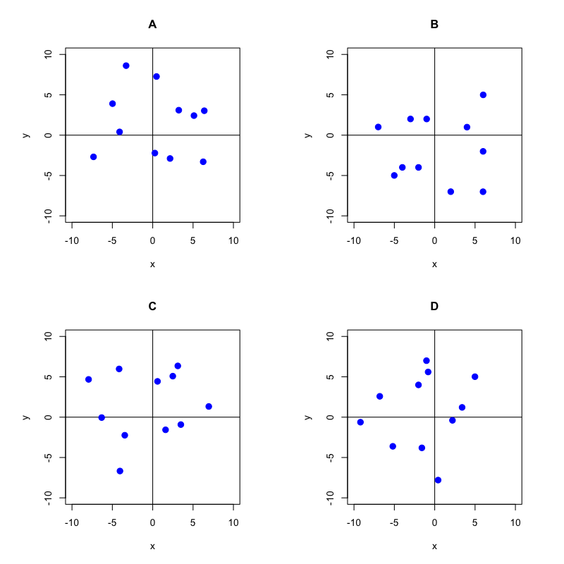

     1. A
     2. B
     3. C
     4. D

#### Solution

#### Question

## Matrix of original points (preimage)

112. A list of 2D-cartesian points is stored as the preimage matrix. Each column represents one point.

     $$P = \begin{bmatrix}
     4 & 6 & 1 & -6 & 3 & 3 & 5 & 5 & -5 & 3 & -4 & -2\\
     -3 & 2 & 6 & 4 & 2 & -6 & -1 & 3 & 1 & -6 & -3 & 5
     \end{bmatrix}$$

     ```
     P = matrix([[4,6,1,-6,3,3,5,5,-5,3,-4,-2],[-3,2,6,4,2,-6,-1,3,1,-6,-3,5]])
     ```

## Rotation matrix

     We want to rotate the points by $\theta=4.44$ radians counterclockwise. We will do this by [matrix multiplication with the 2D rotation matrix](https://en.wikipedia.org/wiki/Rotation_matrix).

     $$R = \begin{bmatrix}\cos(\theta) & -\sin(\theta) \\ \sin(\theta) & \cos(\theta) \end{bmatrix}$$

## Image

     We can apply the rotation to the points through matrix multiplication. Remember, matrix multiplication is not commutative. Let $T$ represent a matrix holding the final positions of the image (after the transformation).

     $$T = RP$$

     After you calculate $T$, you can plot the points in $T$ with the following code (in SageMath):

     ```
     point(T.transpose(),xmin=-10,xmax=10,ymin=-10,ymax=10,size=50)
     ```

     Which is the graph of the points in $T$? (Please excuse minor stylistic differences due to my graphs being made in R, not SageMath.)

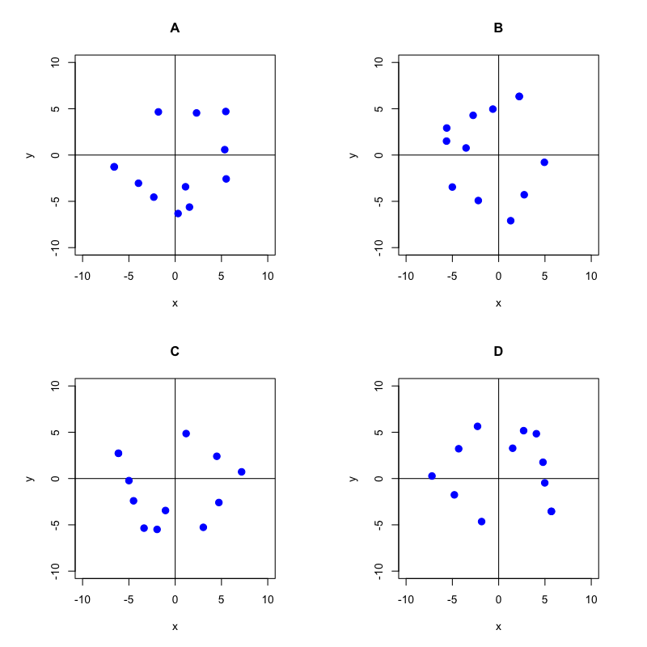

     1. A
     2. B
     3. C
     4. D

#### Solution

#### Question

## Matrix of original points (preimage)

113. A list of 2D-cartesian points is stored as the preimage matrix. Each column represents one point.

     $$P = \begin{bmatrix}
     -7 & -3 & -5 & 4 & -1 & 7 & 3 & -7 & -5 & 4 & -6\\
     -3 & 4 & -5 & 7 & -1 & 2 & -6 & -1 & -5 & 6 & 0
     \end{bmatrix}$$

     ```
     P = matrix([[-7,-3,-5,4,-1,7,3,-7,-5,4,-6],[-3,4,-5,7,-1,2,-6,-1,-5,6,0]])
     ```

## Rotation matrix

     We want to rotate the points by $\theta=4.98$ radians counterclockwise. We will do this by [matrix multiplication with the 2D rotation matrix](https://en.wikipedia.org/wiki/Rotation_matrix).

     $$R = \begin{bmatrix}\cos(\theta) & -\sin(\theta) \\ \sin(\theta) & \cos(\theta) \end{bmatrix}$$

## Image

     We can apply the rotation to the points through matrix multiplication. Remember, matrix multiplication is not commutative. Let $T$ represent a matrix holding the final positions of the image (after the transformation).

     $$T = RP$$

     After you calculate $T$, you can plot the points in $T$ with the following code (in SageMath):

     ```
     point(T.transpose(),xmin=-10,xmax=10,ymin=-10,ymax=10,size=50)
     ```

     Which is the graph of the points in $T$? (Please excuse minor stylistic differences due to my graphs being made in R, not SageMath.)

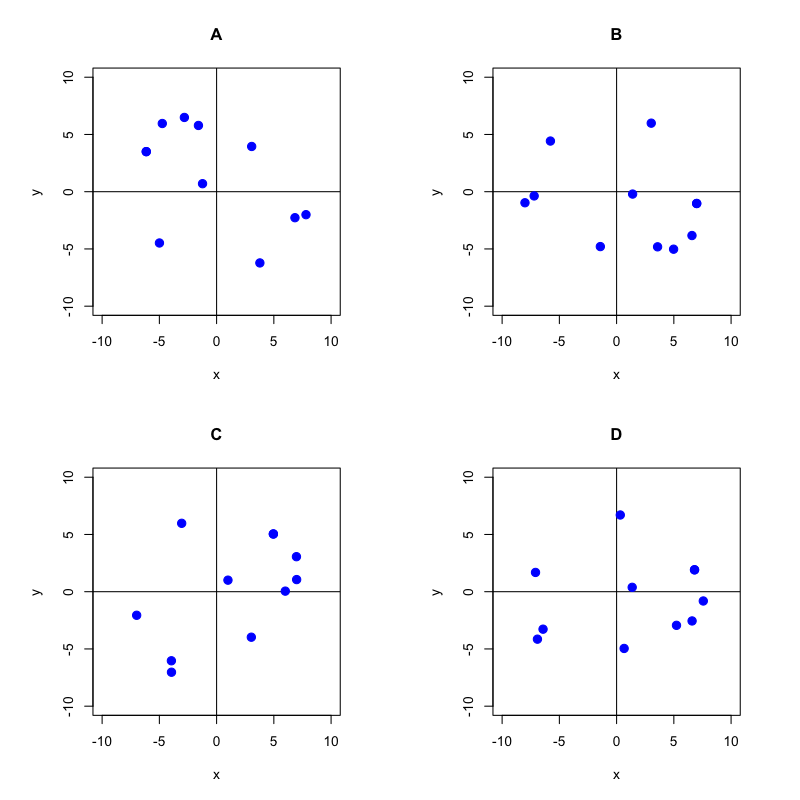

     1. A
     2. B
     3. C
     4. D

#### Solution

#### Question

## Matrix of original points (preimage)

114. A list of 2D-cartesian points is stored as the preimage matrix. Each column represents one point.

     $$P = \begin{bmatrix}
     3 & 5 & 3 & 3 & -5 & 1 & 5 & -4 & 1 & 7 & 6 & 2\\
     -1 & 0 & 7 & 1 & 0 & 1 & -7 & -7 & -1 & -6 & 0 & -1
     \end{bmatrix}$$

     ```
     P = matrix([[3,5,3,3,-5,1,5,-4,1,7,6,2],[-1,0,7,1,0,1,-7,-7,-1,-6,0,-1]])
     ```

## Rotation matrix

     We want to rotate the points by $\theta=5.37$ radians counterclockwise. We will do this by [matrix multiplication with the 2D rotation matrix](https://en.wikipedia.org/wiki/Rotation_matrix).

     $$R = \begin{bmatrix}\cos(\theta) & -\sin(\theta) \\ \sin(\theta) & \cos(\theta) \end{bmatrix}$$

## Image

     We can apply the rotation to the points through matrix multiplication. Remember, matrix multiplication is not commutative. Let $T$ represent a matrix holding the final positions of the image (after the transformation).

     $$T = RP$$

     After you calculate $T$, you can plot the points in $T$ with the following code (in SageMath):

     ```
     point(T.transpose(),xmin=-10,xmax=10,ymin=-10,ymax=10,size=50)
     ```

     Which is the graph of the points in $T$? (Please excuse minor stylistic differences due to my graphs being made in R, not SageMath.)

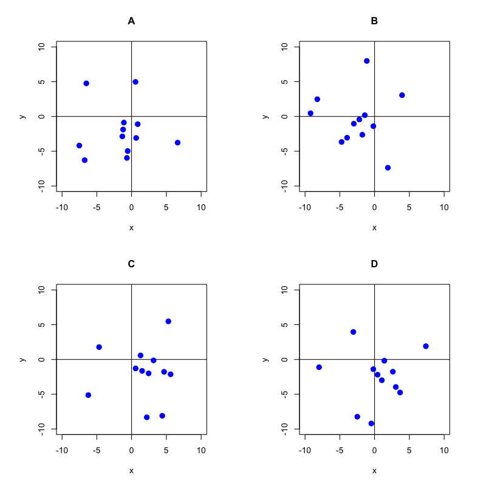

     1. A
     2. B
     3. C
     4. D

#### Solution

#### Question

## Matrix of original points (preimage)

115. A list of 2D-cartesian points is stored as the preimage matrix. Each column represents one point.

     $$P = \begin{bmatrix}
     -5 & -7 & 7 & -7 & 6 & 2 & 6 & -6 & -2 & 6 & -5\\
     -2 & 0 & -6 & -1 & 6 & 2 & -7 & 1 & -1 & -7 & 5
     \end{bmatrix}$$

     ```
     P = matrix([[-5,-7,7,-7,6,2,6,-6,-2,6,-5],[-2,0,-6,-1,6,2,-7,1,-1,-7,5]])
     ```

## Rotation matrix

     We want to rotate the points by $\theta=3.36$ radians counterclockwise. We will do this by [matrix multiplication with the 2D rotation matrix](https://en.wikipedia.org/wiki/Rotation_matrix).

     $$R = \begin{bmatrix}\cos(\theta) & -\sin(\theta) \\ \sin(\theta) & \cos(\theta) \end{bmatrix}$$

## Image

     We can apply the rotation to the points through matrix multiplication. Remember, matrix multiplication is not commutative. Let $T$ represent a matrix holding the final positions of the image (after the transformation).

     $$T = RP$$

     After you calculate $T$, you can plot the points in $T$ with the following code (in SageMath):

     ```
     point(T.transpose(),xmin=-10,xmax=10,ymin=-10,ymax=10,size=50)
     ```

     Which is the graph of the points in $T$? (Please excuse minor stylistic differences due to my graphs being made in R, not SageMath.)

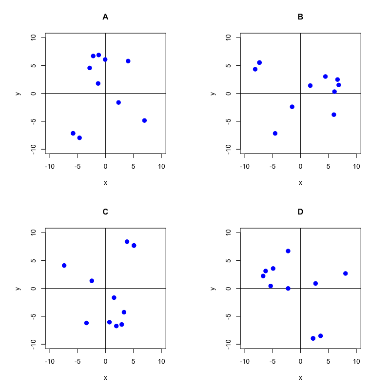

     1. A
     2. B
     3. C
     4. D

#### Solution

#### Question

## Matrix of original points (preimage)

116. A list of 2D-cartesian points is stored as the preimage matrix. Each column represents one point.

     $$P = \begin{bmatrix}
     -2 & -4 & -4 & -7 & -4 & 7 & -5 & 7 & 7\\
     -1 & -2 & 6 & 2 & 7 & -6 & -4 & -6 & 7
     \end{bmatrix}$$

     ```
     P = matrix([[-2,-4,-4,-7,-4,7,-5,7,7],[-1,-2,6,2,7,-6,-4,-6,7]])
     ```

## Rotation matrix

     We want to rotate the points by $\theta=0.71$ radians counterclockwise. We will do this by [matrix multiplication with the 2D rotation matrix](https://en.wikipedia.org/wiki/Rotation_matrix).

     $$R = \begin{bmatrix}\cos(\theta) & -\sin(\theta) \\ \sin(\theta) & \cos(\theta) \end{bmatrix}$$

## Image

     We can apply the rotation to the points through matrix multiplication. Remember, matrix multiplication is not commutative. Let $T$ represent a matrix holding the final positions of the image (after the transformation).

     $$T = RP$$

     After you calculate $T$, you can plot the points in $T$ with the following code (in SageMath):

     ```
     point(T.transpose(),xmin=-10,xmax=10,ymin=-10,ymax=10,size=50)
     ```

     Which is the graph of the points in $T$? (Please excuse minor stylistic differences due to my graphs being made in R, not SageMath.)

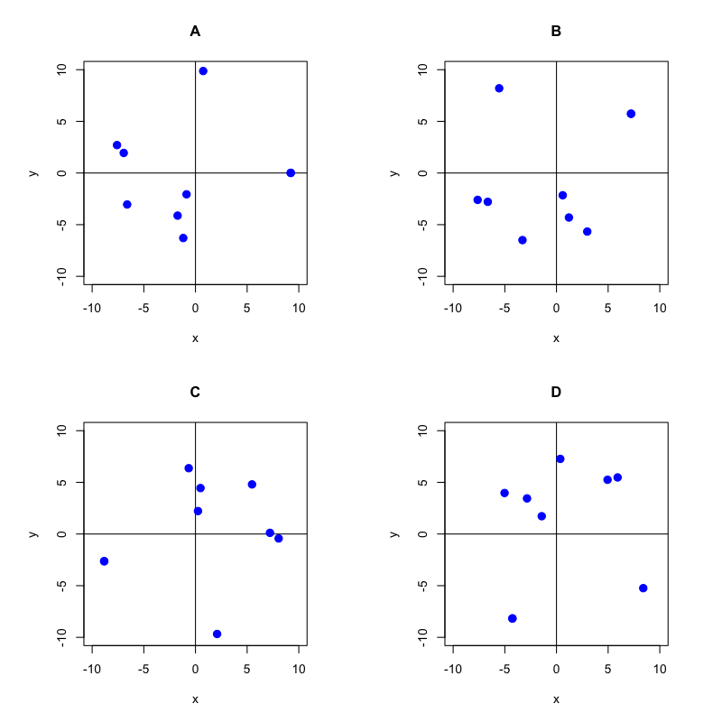

     1. A
     2. B
     3. C
     4. D

#### Solution

#### Question

## Matrix of original points (preimage)

117. A list of 2D-cartesian points is stored as the preimage matrix. Each column represents one point.

     $$P = \begin{bmatrix}
     -2 & 2 & 6 & 2 & -7 & 5 & 5 & -2 & 5\\
     -7 & 5 & 4 & -6 & 6 & 6 & -5 & 6 & -3
     \end{bmatrix}$$

     ```
     P = matrix([[-2,2,6,2,-7,5,5,-2,5],[-7,5,4,-6,6,6,-5,6,-3]])
     ```

## Rotation matrix

     We want to rotate the points by $\theta=4.63$ radians counterclockwise. We will do this by [matrix multiplication with the 2D rotation matrix](https://en.wikipedia.org/wiki/Rotation_matrix).

     $$R = \begin{bmatrix}\cos(\theta) & -\sin(\theta) \\ \sin(\theta) & \cos(\theta) \end{bmatrix}$$

## Image

     We can apply the rotation to the points through matrix multiplication. Remember, matrix multiplication is not commutative. Let $T$ represent a matrix holding the final positions of the image (after the transformation).

     $$T = RP$$

     After you calculate $T$, you can plot the points in $T$ with the following code (in SageMath):

     ```
     point(T.transpose(),xmin=-10,xmax=10,ymin=-10,ymax=10,size=50)
     ```

     Which is the graph of the points in $T$? (Please excuse minor stylistic differences due to my graphs being made in R, not SageMath.)

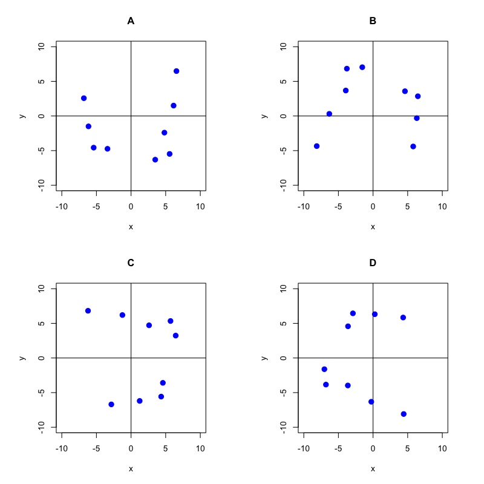

     1. A
     2. B
     3. C
     4. D

#### Solution

#### Question

## Matrix of original points (preimage)

118. A list of 2D-cartesian points is stored as the preimage matrix. Each column represents one point.

     $$P = \begin{bmatrix}
     -2 & -1 & 0 & 4 & -4 & -6 & -3 & 2 & 6 & 7 & -1 & -1\\
     5 & -2 & -7 & 7 & 6 & 2 & -7 & -4 & -1 & -3 & 6 & -6
     \end{bmatrix}$$

     ```
     P = matrix([[-2,-1,0,4,-4,-6,-3,2,6,7,-1,-1],[5,-2,-7,7,6,2,-7,-4,-1,-3,6,-6]])
     ```

## Rotation matrix

     We want to rotate the points by $\theta=1.42$ radians counterclockwise. We will do this by [matrix multiplication with the 2D rotation matrix](https://en.wikipedia.org/wiki/Rotation_matrix).

     $$R = \begin{bmatrix}\cos(\theta) & -\sin(\theta) \\ \sin(\theta) & \cos(\theta) \end{bmatrix}$$

## Image

     We can apply the rotation to the points through matrix multiplication. Remember, matrix multiplication is not commutative. Let $T$ represent a matrix holding the final positions of the image (after the transformation).

     $$T = RP$$

     After you calculate $T$, you can plot the points in $T$ with the following code (in SageMath):

     ```
     point(T.transpose(),xmin=-10,xmax=10,ymin=-10,ymax=10,size=50)
     ```

     Which is the graph of the points in $T$? (Please excuse minor stylistic differences due to my graphs being made in R, not SageMath.)

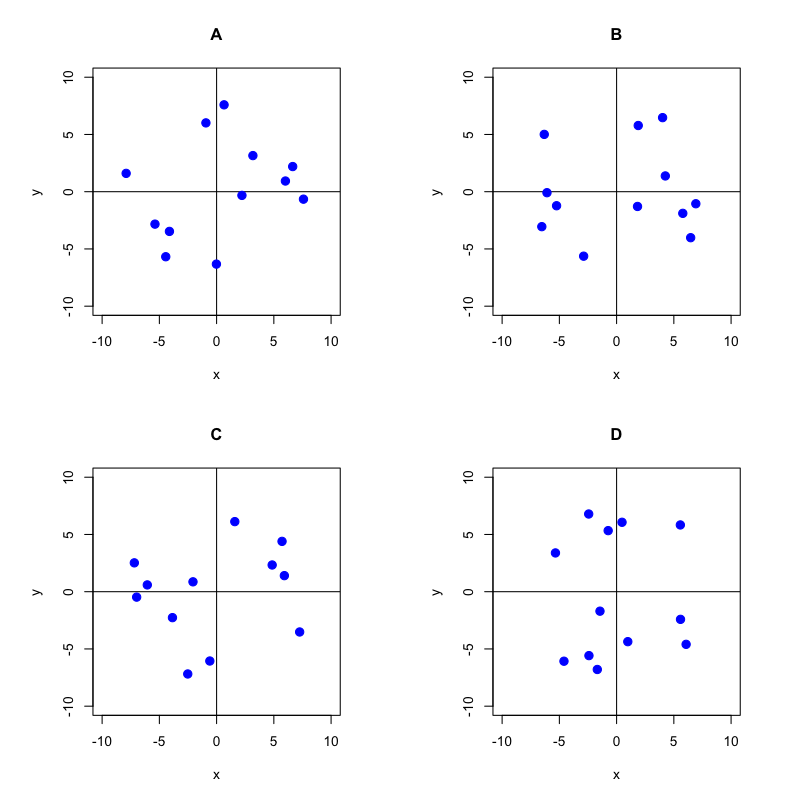

     1. A
     2. B
     3. C
     4. D

#### Solution

#### Question

## Matrix of original points (preimage)

119. A list of 2D-cartesian points is stored as the preimage matrix. Each column represents one point.

     $$P = \begin{bmatrix}
     0 & -3 & -4 & -4 & 6 & -4 & 3 & 4 & -3 & 6\\
     3 & -1 & -2 & -4 & -4 & -5 & -2 & -7 & -5 & -7
     \end{bmatrix}$$

     ```
     P = matrix([[0,-3,-4,-4,6,-4,3,4,-3,6],[3,-1,-2,-4,-4,-5,-2,-7,-5,-7]])
     ```

## Rotation matrix

     We want to rotate the points by $\theta=0.88$ radians counterclockwise. We will do this by [matrix multiplication with the 2D rotation matrix](https://en.wikipedia.org/wiki/Rotation_matrix).

     $$R = \begin{bmatrix}\cos(\theta) & -\sin(\theta) \\ \sin(\theta) & \cos(\theta) \end{bmatrix}$$

## Image

     We can apply the rotation to the points through matrix multiplication. Remember, matrix multiplication is not commutative. Let $T$ represent a matrix holding the final positions of the image (after the transformation).

     $$T = RP$$

     After you calculate $T$, you can plot the points in $T$ with the following code (in SageMath):

     ```
     point(T.transpose(),xmin=-10,xmax=10,ymin=-10,ymax=10,size=50)
     ```

     Which is the graph of the points in $T$? (Please excuse minor stylistic differences due to my graphs being made in R, not SageMath.)

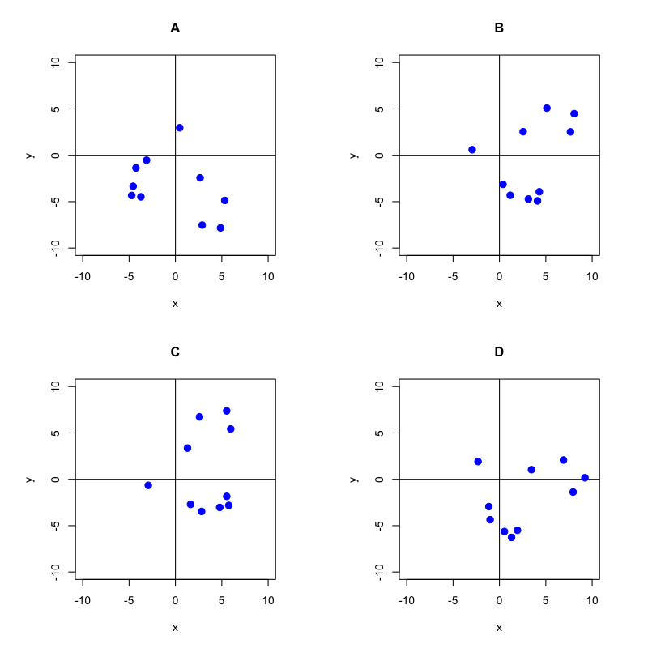

     1. A
     2. B
     3. C
     4. D

#### Solution

#### Question

## Matrix of original points (preimage)

120. A list of 2D-cartesian points is stored as the preimage matrix. Each column represents one point.

     $$P = \begin{bmatrix}
     7 & -5 & -4 & 7 & 4 & -3 & 1 & -6 & -2 & 4 & 3 & -5\\
     6 & -2 & 5 & 1 & -5 & -5 & -6 & 7 & -2 & 0 & 7 & -3
     \end{bmatrix}$$

     ```
     P = matrix([[7,-5,-4,7,4,-3,1,-6,-2,4,3,-5],[6,-2,5,1,-5,-5,-6,7,-2,0,7,-3]])
     ```

## Rotation matrix

     We want to rotate the points by $\theta=4.12$ radians counterclockwise. We will do this by [matrix multiplication with the 2D rotation matrix](https://en.wikipedia.org/wiki/Rotation_matrix).

     $$R = \begin{bmatrix}\cos(\theta) & -\sin(\theta) \\ \sin(\theta) & \cos(\theta) \end{bmatrix}$$

## Image

     We can apply the rotation to the points through matrix multiplication. Remember, matrix multiplication is not commutative. Let $T$ represent a matrix holding the final positions of the image (after the transformation).

     $$T = RP$$

     After you calculate $T$, you can plot the points in $T$ with the following code (in SageMath):

     ```
     point(T.transpose(),xmin=-10,xmax=10,ymin=-10,ymax=10,size=50)
     ```

     Which is the graph of the points in $T$? (Please excuse minor stylistic differences due to my graphs being made in R, not SageMath.)

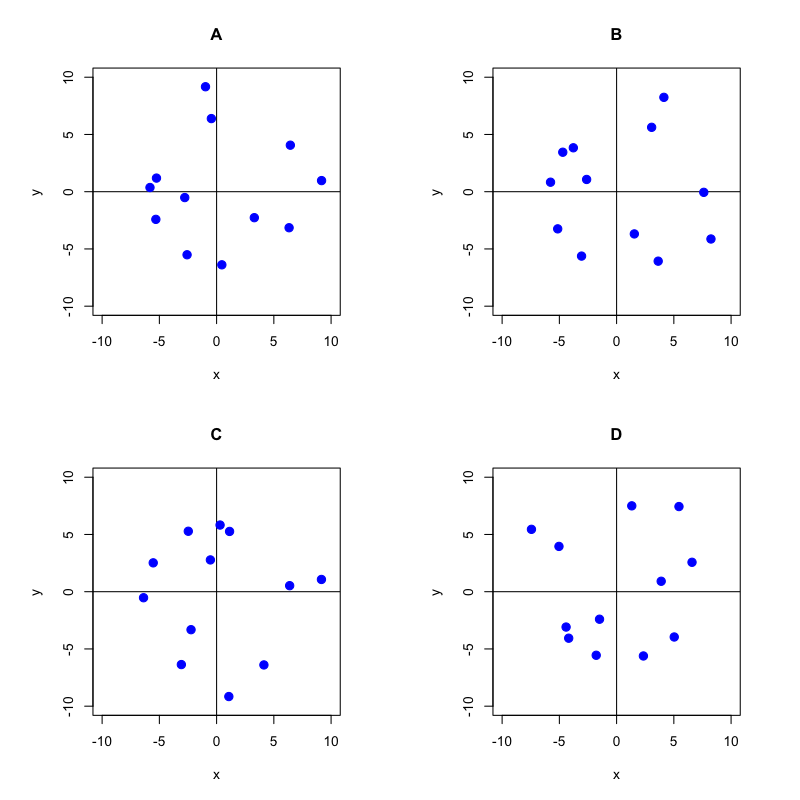

     1. A
     2. B
     3. C
     4. D

#### Solution

#### Question

121. Some basic [2D-transformation matrices](https://en.wikipedia.org/wiki/Transformation_matrix) are shown:
     - Horizontal stretch by factor $k$ (reflection if $k=-1$).
       $$\begin{bmatrix}k & 0 \\ 0 & 1\end{bmatrix}$$
     - Vertical stretch by factor $k$ (reflection if $k=-1$).
       $$\begin{bmatrix}1 & 0 \\ 0 & k\end{bmatrix}$$
     - Rotation by angle $\theta$ radians.
       $$\begin{bmatrix}\cos(\theta) & -\sin(\theta) \\ \sin(\theta) & \cos(\theta)\end{bmatrix}$$
     - Horizontal shearing by factor $k$.
       $$\begin{bmatrix}1 & k \\ 0 & 1\end{bmatrix}$$
     - Vertical shearing by factor $k$.
       $$\begin{bmatrix}1 & 0 \\ k & 1\end{bmatrix}$$

     When multiple transformations are applied, order matters. If $A$ was the matrix of the first transformation, $B$ was the matrix of the second transformation, $C$ was the matrix of the third transformation, and $X$ was a matrix of column vectors, then the result, $X'$, would be found with the following matrix multiplication:
     $$X' = CBAX$$
     Notice, the order seems backwards; this is standard.

## Problem-specific information

     Begin with the points of a unit square.

     $$X = \begin{bmatrix}0 & 1 & 1 & 0 \\ 0 & 0 & 1 & 1\end{bmatrix}$$

     ```
     X = matrix([[0,1,1,0],[0,0,1,1]])
     polygon(X.transpose(),xmin=-5,xmax=5,ymin=-5,ymax=5,aspect_ratio=1,color="red")
     ```

     Apply the following transformations in the indicated order:
     1. A rotation by angle 4.24.
     2. A vertical shear by factor 2.2.
     3. A horizontal shear by factor 1.5.

     Which graph is generated when polygon $X$ is plotted in red and polygon $X'$ is plotted in blue?

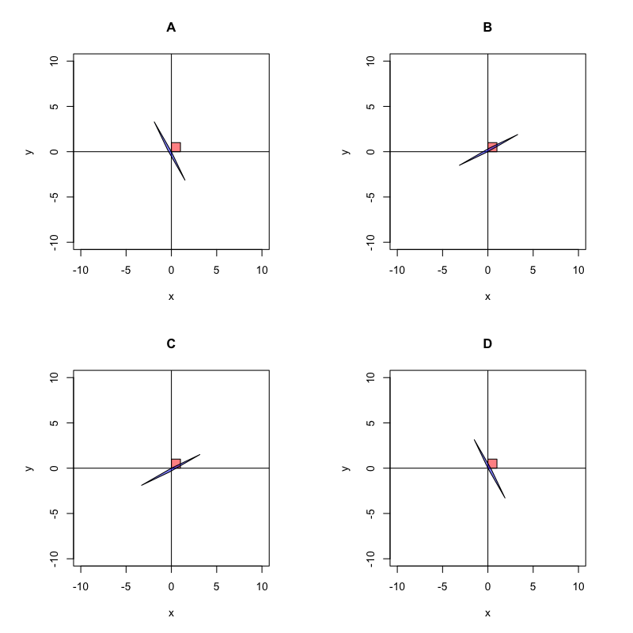

     1. A
     2. B
     3. C
     4. D

#### Solution

#### Question

122. Some basic [2D-transformation matrices](https://en.wikipedia.org/wiki/Transformation_matrix) are shown:
     - Horizontal stretch by factor $k$ (reflection if $k=-1$).
       $$\begin{bmatrix}k & 0 \\ 0 & 1\end{bmatrix}$$
     - Vertical stretch by factor $k$ (reflection if $k=-1$).
       $$\begin{bmatrix}1 & 0 \\ 0 & k\end{bmatrix}$$
     - Rotation by angle $\theta$ radians.
       $$\begin{bmatrix}\cos(\theta) & -\sin(\theta) \\ \sin(\theta) & \cos(\theta)\end{bmatrix}$$
     - Horizontal shearing by factor $k$.
       $$\begin{bmatrix}1 & k \\ 0 & 1\end{bmatrix}$$
     - Vertical shearing by factor $k$.
       $$\begin{bmatrix}1 & 0 \\ k & 1\end{bmatrix}$$

     When multiple transformations are applied, order matters. If $A$ was the matrix of the first transformation, $B$ was the matrix of the second transformation, $C$ was the matrix of the third transformation, and $X$ was a matrix of column vectors, then the result, $X'$, would be found with the following matrix multiplication:
     $$X' = CBAX$$
     Notice, the order seems backwards; this is standard.

## Problem-specific information

     Begin with the points of a unit square.

     $$X = \begin{bmatrix}0 & 1 & 1 & 0 \\ 0 & 0 & 1 & 1\end{bmatrix}$$

     ```
     X = matrix([[0,1,1,0],[0,0,1,1]])
     polygon(X.transpose(),xmin=-5,xmax=5,ymin=-5,ymax=5,aspect_ratio=1,color="red")
     ```

     Apply the following transformations in the indicated order:
     1. A horizontal stretch by factor 1.9.
     2. A vertical shear by factor 2.3.
     3. A rotation by angle 4.18.

     Which graph is generated when polygon $X$ is plotted in red and polygon $X'$ is plotted in blue?

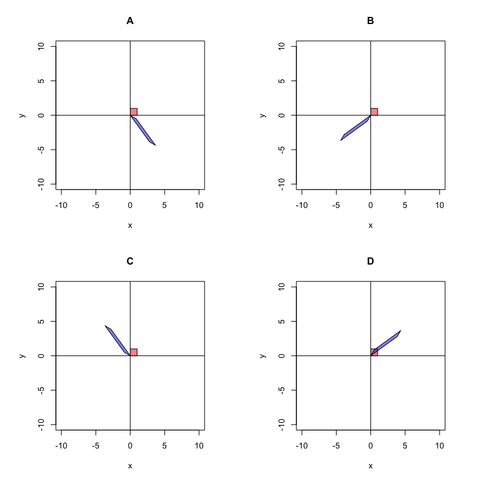

     1. A
     2. B
     3. C
     4. D

#### Solution

#### Question

123. Some basic [2D-transformation matrices](https://en.wikipedia.org/wiki/Transformation_matrix) are shown:
     - Horizontal stretch by factor $k$ (reflection if $k=-1$).
       $$\begin{bmatrix}k & 0 \\ 0 & 1\end{bmatrix}$$
     - Vertical stretch by factor $k$ (reflection if $k=-1$).
       $$\begin{bmatrix}1 & 0 \\ 0 & k\end{bmatrix}$$
     - Rotation by angle $\theta$ radians.
       $$\begin{bmatrix}\cos(\theta) & -\sin(\theta) \\ \sin(\theta) & \cos(\theta)\end{bmatrix}$$
     - Horizontal shearing by factor $k$.
       $$\begin{bmatrix}1 & k \\ 0 & 1\end{bmatrix}$$
     - Vertical shearing by factor $k$.
       $$\begin{bmatrix}1 & 0 \\ k & 1\end{bmatrix}$$

     When multiple transformations are applied, order matters. If $A$ was the matrix of the first transformation, $B$ was the matrix of the second transformation, $C$ was the matrix of the third transformation, and $X$ was a matrix of column vectors, then the result, $X'$, would be found with the following matrix multiplication:
     $$X' = CBAX$$
     Notice, the order seems backwards; this is standard.

## Problem-specific information

     Begin with the points of a unit square.

     $$X = \begin{bmatrix}0 & 1 & 1 & 0 \\ 0 & 0 & 1 & 1\end{bmatrix}$$

     ```
     X = matrix([[0,1,1,0],[0,0,1,1]])
     polygon(X.transpose(),xmin=-5,xmax=5,ymin=-5,ymax=5,aspect_ratio=1,color="red")
     ```

     Apply the following transformations in the indicated order:
     1. A horizontal shear by factor 1.6.
     2. A vertical shear by factor 2.2.
     3. A rotation by angle 4.89.

     Which graph is generated when polygon $X$ is plotted in red and polygon $X'$ is plotted in blue?

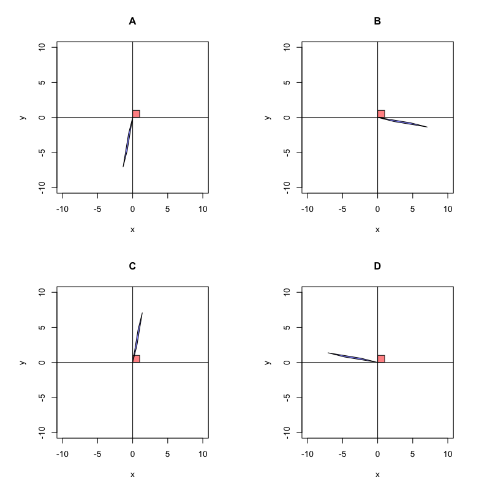

     1. A
     2. B
     3. C
     4. D

#### Solution

#### Question

124. Some basic [2D-transformation matrices](https://en.wikipedia.org/wiki/Transformation_matrix) are shown:
     - Horizontal stretch by factor $k$ (reflection if $k=-1$).
       $$\begin{bmatrix}k & 0 \\ 0 & 1\end{bmatrix}$$
     - Vertical stretch by factor $k$ (reflection if $k=-1$).
       $$\begin{bmatrix}1 & 0 \\ 0 & k\end{bmatrix}$$
     - Rotation by angle $\theta$ radians.
       $$\begin{bmatrix}\cos(\theta) & -\sin(\theta) \\ \sin(\theta) & \cos(\theta)\end{bmatrix}$$
     - Horizontal shearing by factor $k$.
       $$\begin{bmatrix}1 & k \\ 0 & 1\end{bmatrix}$$
     - Vertical shearing by factor $k$.
       $$\begin{bmatrix}1 & 0 \\ k & 1\end{bmatrix}$$

     When multiple transformations are applied, order matters. If $A$ was the matrix of the first transformation, $B$ was the matrix of the second transformation, $C$ was the matrix of the third transformation, and $X$ was a matrix of column vectors, then the result, $X'$, would be found with the following matrix multiplication:
     $$X' = CBAX$$
     Notice, the order seems backwards; this is standard.

## Problem-specific information

     Begin with the points of a unit square.

     $$X = \begin{bmatrix}0 & 1 & 1 & 0 \\ 0 & 0 & 1 & 1\end{bmatrix}$$

     ```
     X = matrix([[0,1,1,0],[0,0,1,1]])
     polygon(X.transpose(),xmin=-5,xmax=5,ymin=-5,ymax=5,aspect_ratio=1,color="red")
     ```

     Apply the following transformations in the indicated order:
     1. A horizontal stretch by factor 2.3.
     2. A rotation by angle 0.4.
     3. A vertical stretch by factor 1.7.

     Which graph is generated when polygon $X$ is plotted in red and polygon $X'$ is plotted in blue?

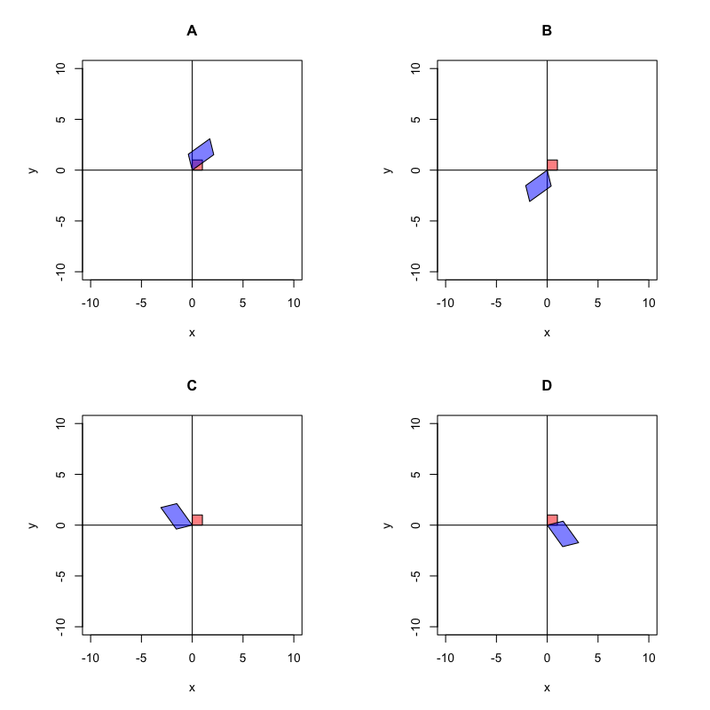

     1. A
     2. B
     3. C
     4. D

#### Solution

#### Question

125. Some basic [2D-transformation matrices](https://en.wikipedia.org/wiki/Transformation_matrix) are shown:
     - Horizontal stretch by factor $k$ (reflection if $k=-1$).
       $$\begin{bmatrix}k & 0 \\ 0 & 1\end{bmatrix}$$
     - Vertical stretch by factor $k$ (reflection if $k=-1$).
       $$\begin{bmatrix}1 & 0 \\ 0 & k\end{bmatrix}$$
     - Rotation by angle $\theta$ radians.
       $$\begin{bmatrix}\cos(\theta) & -\sin(\theta) \\ \sin(\theta) & \cos(\theta)\end{bmatrix}$$
     - Horizontal shearing by factor $k$.
       $$\begin{bmatrix}1 & k \\ 0 & 1\end{bmatrix}$$
     - Vertical shearing by factor $k$.
       $$\begin{bmatrix}1 & 0 \\ k & 1\end{bmatrix}$$

     When multiple transformations are applied, order matters. If $A$ was the matrix of the first transformation, $B$ was the matrix of the second transformation, $C$ was the matrix of the third transformation, and $X$ was a matrix of column vectors, then the result, $X'$, would be found with the following matrix multiplication:
     $$X' = CBAX$$
     Notice, the order seems backwards; this is standard.

## Problem-specific information

     Begin with the points of a unit square.

     $$X = \begin{bmatrix}0 & 1 & 1 & 0 \\ 0 & 0 & 1 & 1\end{bmatrix}$$

     ```
     X = matrix([[0,1,1,0],[0,0,1,1]])
     polygon(X.transpose(),xmin=-5,xmax=5,ymin=-5,ymax=5,aspect_ratio=1,color="red")
     ```

     Apply the following transformations in the indicated order:
     1. A vertical shear by factor 2.2.
     2. A rotation by angle 0.53.
     3. A horizontal shear by factor 1.3.

     Which graph is generated when polygon $X$ is plotted in red and polygon $X'$ is plotted in blue?

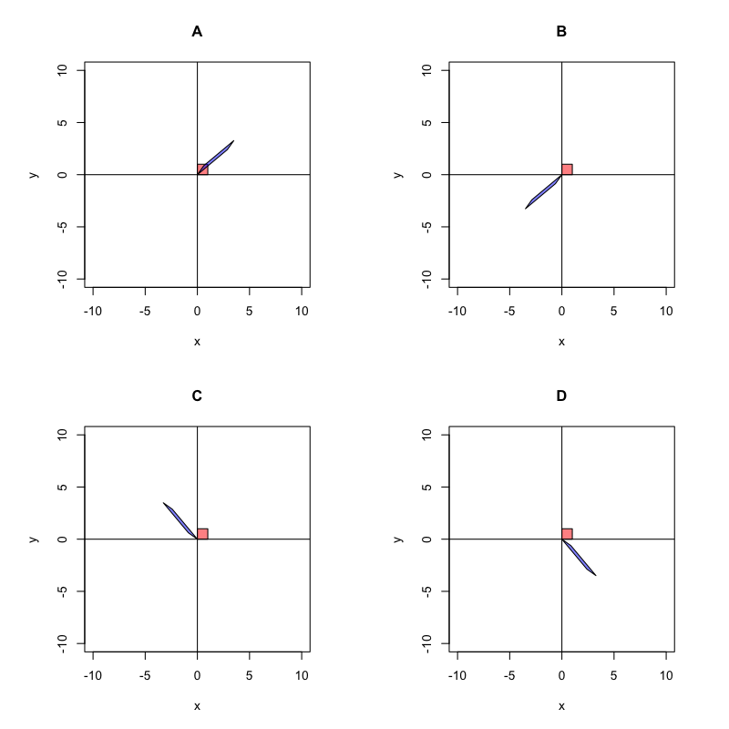

     1. A
     2. B
     3. C
     4. D

#### Solution

#### Question

126. Some basic [2D-transformation matrices](https://en.wikipedia.org/wiki/Transformation_matrix) are shown:
     - Horizontal stretch by factor $k$ (reflection if $k=-1$).
       $$\begin{bmatrix}k & 0 \\ 0 & 1\end{bmatrix}$$
     - Vertical stretch by factor $k$ (reflection if $k=-1$).
       $$\begin{bmatrix}1 & 0 \\ 0 & k\end{bmatrix}$$
     - Rotation by angle $\theta$ radians.
       $$\begin{bmatrix}\cos(\theta) & -\sin(\theta) \\ \sin(\theta) & \cos(\theta)\end{bmatrix}$$
     - Horizontal shearing by factor $k$.
       $$\begin{bmatrix}1 & k \\ 0 & 1\end{bmatrix}$$
     - Vertical shearing by factor $k$.
       $$\begin{bmatrix}1 & 0 \\ k & 1\end{bmatrix}$$

     When multiple transformations are applied, order matters. If $A$ was the matrix of the first transformation, $B$ was the matrix of the second transformation, $C$ was the matrix of the third transformation, and $X$ was a matrix of column vectors, then the result, $X'$, would be found with the following matrix multiplication:
     $$X' = CBAX$$
     Notice, the order seems backwards; this is standard.

## Problem-specific information

     Begin with the points of a unit square.

     $$X = \begin{bmatrix}0 & 1 & 1 & 0 \\ 0 & 0 & 1 & 1\end{bmatrix}$$

     ```
     X = matrix([[0,1,1,0],[0,0,1,1]])
     polygon(X.transpose(),xmin=-5,xmax=5,ymin=-5,ymax=5,aspect_ratio=1,color="red")
     ```

     Apply the following transformations in the indicated order:
     1. A vertical shear by factor 1.5.
     2. A vertical stretch by factor 1.3.
     3. A rotation by angle 2.79.

     Which graph is generated when polygon $X$ is plotted in red and polygon $X'$ is plotted in blue?

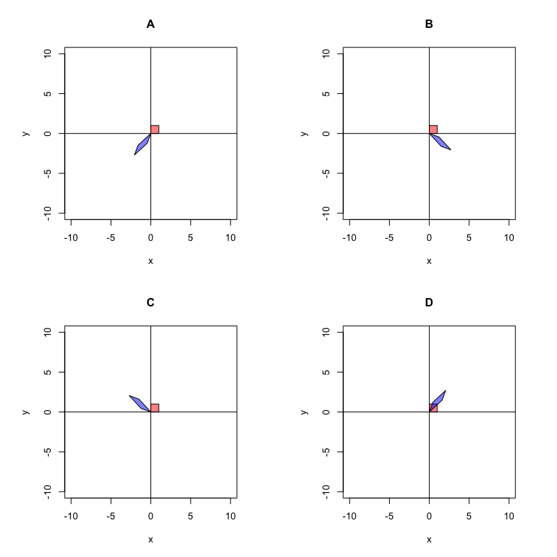

     1. A
     2. B
     3. C
     4. D

#### Solution

#### Question

127. Some basic [2D-transformation matrices](https://en.wikipedia.org/wiki/Transformation_matrix) are shown:
     - Horizontal stretch by factor $k$ (reflection if $k=-1$).
       $$\begin{bmatrix}k & 0 \\ 0 & 1\end{bmatrix}$$
     - Vertical stretch by factor $k$ (reflection if $k=-1$).
       $$\begin{bmatrix}1 & 0 \\ 0 & k\end{bmatrix}$$
     - Rotation by angle $\theta$ radians.
       $$\begin{bmatrix}\cos(\theta) & -\sin(\theta) \\ \sin(\theta) & \cos(\theta)\end{bmatrix}$$
     - Horizontal shearing by factor $k$.
       $$\begin{bmatrix}1 & k \\ 0 & 1\end{bmatrix}$$
     - Vertical shearing by factor $k$.
       $$\begin{bmatrix}1 & 0 \\ k & 1\end{bmatrix}$$

     When multiple transformations are applied, order matters. If $A$ was the matrix of the first transformation, $B$ was the matrix of the second transformation, $C$ was the matrix of the third transformation, and $X$ was a matrix of column vectors, then the result, $X'$, would be found with the following matrix multiplication:
     $$X' = CBAX$$
     Notice, the order seems backwards; this is standard.

## Problem-specific information

     Begin with the points of a unit square.

     $$X = \begin{bmatrix}0 & 1 & 1 & 0 \\ 0 & 0 & 1 & 1\end{bmatrix}$$

     ```
     X = matrix([[0,1,1,0],[0,0,1,1]])
     polygon(X.transpose(),xmin=-5,xmax=5,ymin=-5,ymax=5,aspect_ratio=1,color="red")
     ```

     Apply the following transformations in the indicated order:
     1. A rotation by angle 3.41.
     2. A horizontal shear by factor 2.2.
     3. A vertical shear by factor 1.7.

     Which graph is generated when polygon $X$ is plotted in red and polygon $X'$ is plotted in blue?

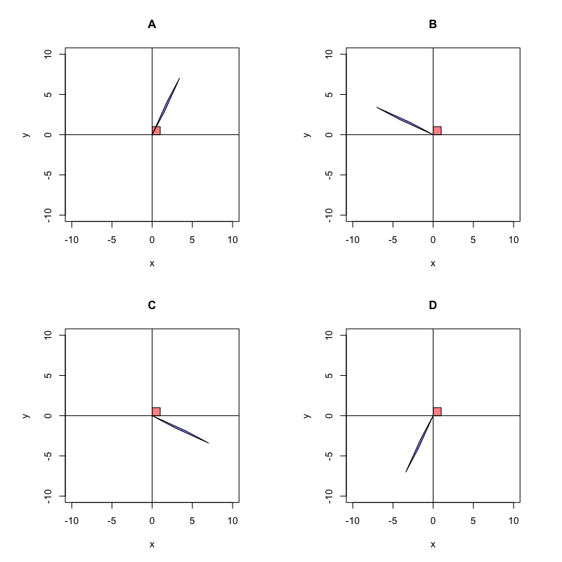

     1. A
     2. B
     3. C
     4. D

#### Solution

#### Question

128. Some basic [2D-transformation matrices](https://en.wikipedia.org/wiki/Transformation_matrix) are shown:
     - Horizontal stretch by factor $k$ (reflection if $k=-1$).
       $$\begin{bmatrix}k & 0 \\ 0 & 1\end{bmatrix}$$
     - Vertical stretch by factor $k$ (reflection if $k=-1$).
       $$\begin{bmatrix}1 & 0 \\ 0 & k\end{bmatrix}$$
     - Rotation by angle $\theta$ radians.
       $$\begin{bmatrix}\cos(\theta) & -\sin(\theta) \\ \sin(\theta) & \cos(\theta)\end{bmatrix}$$
     - Horizontal shearing by factor $k$.
       $$\begin{bmatrix}1 & k \\ 0 & 1\end{bmatrix}$$
     - Vertical shearing by factor $k$.
       $$\begin{bmatrix}1 & 0 \\ k & 1\end{bmatrix}$$

     When multiple transformations are applied, order matters. If $A$ was the matrix of the first transformation, $B$ was the matrix of the second transformation, $C$ was the matrix of the third transformation, and $X$ was a matrix of column vectors, then the result, $X'$, would be found with the following matrix multiplication:
     $$X' = CBAX$$
     Notice, the order seems backwards; this is standard.

## Problem-specific information

     Begin with the points of a unit square.

     $$X = \begin{bmatrix}0 & 1 & 1 & 0 \\ 0 & 0 & 1 & 1\end{bmatrix}$$

     ```
     X = matrix([[0,1,1,0],[0,0,1,1]])
     polygon(X.transpose(),xmin=-5,xmax=5,ymin=-5,ymax=5,aspect_ratio=1,color="red")
     ```

     Apply the following transformations in the indicated order:
     1. A rotation by angle 2.46.
     2. A vertical shear by factor 1.8.
     3. A horizontal shear by factor 2.3.

     Which graph is generated when polygon $X$ is plotted in red and polygon $X'$ is plotted in blue?

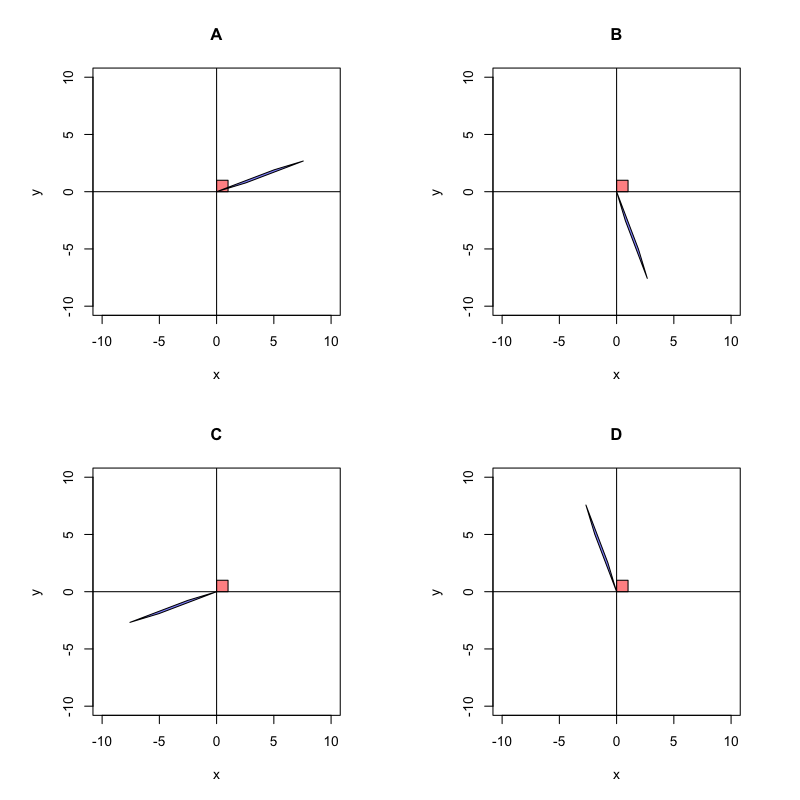

     1. A
     2. B
     3. C
     4. D

#### Solution

#### Question

129. Some basic [2D-transformation matrices](https://en.wikipedia.org/wiki/Transformation_matrix) are shown:
     - Horizontal stretch by factor $k$ (reflection if $k=-1$).
       $$\begin{bmatrix}k & 0 \\ 0 & 1\end{bmatrix}$$
     - Vertical stretch by factor $k$ (reflection if $k=-1$).
       $$\begin{bmatrix}1 & 0 \\ 0 & k\end{bmatrix}$$
     - Rotation by angle $\theta$ radians.
       $$\begin{bmatrix}\cos(\theta) & -\sin(\theta) \\ \sin(\theta) & \cos(\theta)\end{bmatrix}$$
     - Horizontal shearing by factor $k$.
       $$\begin{bmatrix}1 & k \\ 0 & 1\end{bmatrix}$$
     - Vertical shearing by factor $k$.
       $$\begin{bmatrix}1 & 0 \\ k & 1\end{bmatrix}$$

     When multiple transformations are applied, order matters. If $A$ was the matrix of the first transformation, $B$ was the matrix of the second transformation, $C$ was the matrix of the third transformation, and $X$ was a matrix of column vectors, then the result, $X'$, would be found with the following matrix multiplication:
     $$X' = CBAX$$
     Notice, the order seems backwards; this is standard.

## Problem-specific information

     Begin with the points of a unit square.

     $$X = \begin{bmatrix}0 & 1 & 1 & 0 \\ 0 & 0 & 1 & 1\end{bmatrix}$$

     ```
     X = matrix([[0,1,1,0],[0,0,1,1]])
     polygon(X.transpose(),xmin=-5,xmax=5,ymin=-5,ymax=5,aspect_ratio=1,color="red")
     ```

     Apply the following transformations in the indicated order:
     1. A rotation by angle 2.03.
     2. A vertical stretch by factor 1.6.
     3. A horizontal stretch by factor 1.4.

     Which graph is generated when polygon $X$ is plotted in red and polygon $X'$ is plotted in blue?

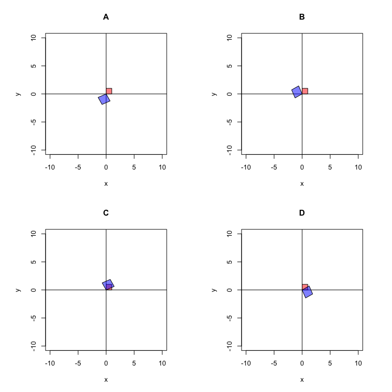

     1. A
     2. B
     3. C
     4. D

#### Solution

#### Question

130. Some basic [2D-transformation matrices](https://en.wikipedia.org/wiki/Transformation_matrix) are shown:
     - Horizontal stretch by factor $k$ (reflection if $k=-1$).
       $$\begin{bmatrix}k & 0 \\ 0 & 1\end{bmatrix}$$
     - Vertical stretch by factor $k$ (reflection if $k=-1$).
       $$\begin{bmatrix}1 & 0 \\ 0 & k\end{bmatrix}$$
     - Rotation by angle $\theta$ radians.
       $$\begin{bmatrix}\cos(\theta) & -\sin(\theta) \\ \sin(\theta) & \cos(\theta)\end{bmatrix}$$
     - Horizontal shearing by factor $k$.
       $$\begin{bmatrix}1 & k \\ 0 & 1\end{bmatrix}$$
     - Vertical shearing by factor $k$.
       $$\begin{bmatrix}1 & 0 \\ k & 1\end{bmatrix}$$

     When multiple transformations are applied, order matters. If $A$ was the matrix of the first transformation, $B$ was the matrix of the second transformation, $C$ was the matrix of the third transformation, and $X$ was a matrix of column vectors, then the result, $X'$, would be found with the following matrix multiplication:
     $$X' = CBAX$$
     Notice, the order seems backwards; this is standard.

## Problem-specific information

     Begin with the points of a unit square.

     $$X = \begin{bmatrix}0 & 1 & 1 & 0 \\ 0 & 0 & 1 & 1\end{bmatrix}$$

     ```
     X = matrix([[0,1,1,0],[0,0,1,1]])
     polygon(X.transpose(),xmin=-5,xmax=5,ymin=-5,ymax=5,aspect_ratio=1,color="red")
     ```

     Apply the following transformations in the indicated order:
     1. A vertical shear by factor 2.3.
     2. A vertical stretch by factor 1.9.
     3. A rotation by angle 3.03.

     Which graph is generated when polygon $X$ is plotted in red and polygon $X'$ is plotted in blue?

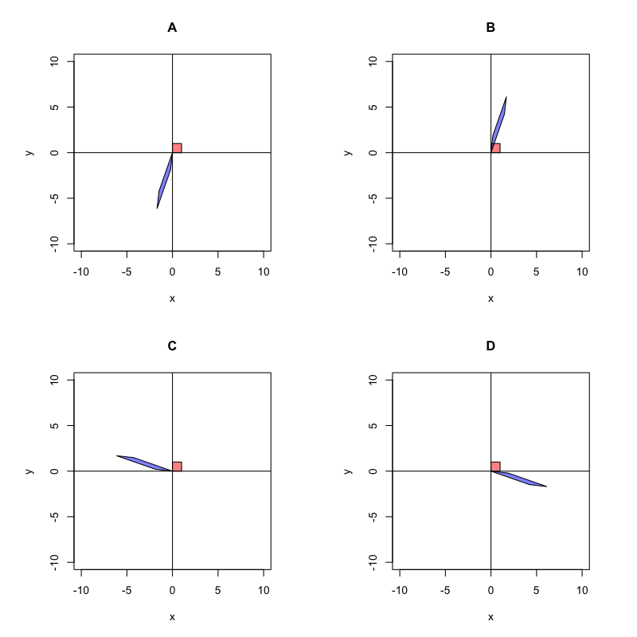

     1. A
     2. B
     3. C
     4. D

#### Solution